# Project: Identify Customer Segments

In this project, you will apply unsupervised learning techniques to identify segments of the population that form the core customer base for a mail-order sales company in Germany. These segments can then be used to direct marketing campaigns towards audiences that will have the highest expected rate of returns. The data that you will use has been provided by our partners at Bertelsmann Arvato Analytics, and represents a real-life data science task.

This notebook will help you complete this task by providing a framework within which you will perform your analysis steps. In each step of the project, you will see some text describing the subtask that you will perform, followed by one or more code cells for you to complete your work. **Feel free to add additional code and markdown cells as you go along so that you can explore everything in precise chunks.** The code cells provided in the base template will outline only the major tasks, and will usually not be enough to cover all of the minor tasks that comprise it.

It should be noted that while there will be precise guidelines on how you should handle certain tasks in the project, there will also be places where an exact specification is not provided. **There will be times in the project where you will need to make and justify your own decisions on how to treat the data.** These are places where there may not be only one way to handle the data. In real-life tasks, there may be many valid ways to approach an analysis task. One of the most important things you can do is clearly document your approach so that other scientists can understand the decisions you've made.

At the end of most sections, there will be a Markdown cell labeled **Discussion**. In these cells, you will report your findings for the completed section, as well as document the decisions that you made in your approach to each subtask. **Your project will be evaluated not just on the code used to complete the tasks outlined, but also your communication about your observations and conclusions at each stage.**

```python
# import libraries here; add more as necessary
import numpy as np
import pandas as pd
import matplotlib.pyplot as plt
import seaborn as sns
from sklearn.preprocessing import StandardScaler
from sklearn.decomposition import PCA
from sklearn.cluster import KMeans

# magic word for producing visualizations in notebook
%matplotlib inline

'''
Import note: The classroom currently uses sklearn version 0.19.
If you need to use an imputer, it is available in sklearn.preprocessing.Imputer,
instead of sklearn.impute as in newer versions of sklearn.
'''
```

```
'\nImport note: The classroom currently uses sklearn version 0.19.\nIf you need to use an imputer, it is available in sklearn.preprocessing.Imputer,\ninstead of sklearn.impute as in newer versions of sklearn.\n'
```

### Step 0: Load the Data

There are four files associated with this project (not including this one):

Each row of the demographics files represents a single person, but also includes information outside of individuals, including information about their household, building, and neighborhood. You will use this information to cluster the general population into groups with similar demographic properties. Then, you will see how the people in the customers dataset fit into those created clusters. The hope here is that certain clusters are over-represented in the customers data, as compared to the general population; those over-represented clusters will be assumed to be part of the core userbase. This information can then be used for further applications, such as targeting for a marketing campaign.

To start off with, load in the demographics data for the general population into a pandas DataFrame, and do the same for the feature attributes summary. Note for all of the `.csv` data files in this project: they're semicolon (`;`) delimited, so you'll need an additional argument in your [`read_csv()`](https://pandas.pydata.org/pandas-docs/stable/generated/pandas.read_csv.html) call to read in the data properly. Also, considering the size of the main dataset, it may take some time for it to load completely.

Once the dataset is loaded, it's recommended that you take a little bit of time just browsing the general structure of the dataset and feature summary file. You'll be getting deep into the innards of the cleaning in the first major step of the project, so gaining some general familiarity can help you get your bearings.

```python
# Load in the general demographics data.
azdias = pd.read_csv('Udacity_AZDIAS_Subset.csv', delimiter = ';')
azdias_orig = azdias.copy()

# Load in the feature summary file.
feat_info = pd.read_csv('AZDIAS_Feature_Summary.csv', delimiter = ';')
```

```python
# Check the structure of the data after it's loaded (e.g. print the number of
# rows and columns, print the first few rows).
azdias.head()
```

|  | AGER_TYP | ALTERSKATEGORIE_GROB | ANREDE_KZ | CJT_GESAMTTYP | FINANZ_MINIMALIST | FINANZ_SPARER | FINANZ_VORSORGER | FINANZ_ANLEGER | FINANZ_UNAUFFAELLIGER | FINANZ_HAUSBAUER | ... | PLZ8_ANTG1 | PLZ8_ANTG2 | PLZ8_ANTG3 | PLZ8_ANTG4 | PLZ8_BAUMAX | PLZ8_HHZ | PLZ8_GBZ | ARBEIT | ORTSGR_KLS9 | RELAT_AB |
| --- | --- | --- | --- | --- | --- | --- | --- | --- | --- | --- | --- | --- | --- | --- | --- | --- | --- | --- | --- | --- | --- |
| 0 | -1 | 2 | 1 | 2.0 | 3 | 4 | 3 | 5 | 5 | 3 | ... | NaN | NaN | NaN | NaN | NaN | NaN | NaN | NaN | NaN | NaN |
| 1 | -1 | 1 | 2 | 5.0 | 1 | 5 | 2 | 5 | 4 | 5 | ... | 2.0 | 3.0 | 2.0 | 1.0 | 1.0 | 5.0 | 4.0 | 3.0 | 5.0 | 4.0 |
| 2 | -1 | 3 | 2 | 3.0 | 1 | 4 | 1 | 2 | 3 | 5 | ... | 3.0 | 3.0 | 1.0 | 0.0 | 1.0 | 4.0 | 4.0 | 3.0 | 5.0 | 2.0 |
| 3 | 2 | 4 | 2 | 2.0 | 4 | 2 | 5 | 2 | 1 | 2 | ... | 2.0 | 2.0 | 2.0 | 0.0 | 1.0 | 3.0 | 4.0 | 2.0 | 3.0 | 3.0 |
| 4 | -1 | 3 | 1 | 5.0 | 4 | 3 | 4 | 1 | 3 | 2 | ... | 2.0 | 4.0 | 2.0 | 1.0 | 2.0 | 3.0 | 3.0 | 4.0 | 6.0 | 5.0 |

5 rows × 85 columns

```python
azdias.describe()
```

|  | AGER_TYP | ALTERSKATEGORIE_GROB | ANREDE_KZ | CJT_GESAMTTYP | FINANZ_MINIMALIST | FINANZ_SPARER | FINANZ_VORSORGER | FINANZ_ANLEGER | FINANZ_UNAUFFAELLIGER | FINANZ_HAUSBAUER | ... | PLZ8_ANTG1 | PLZ8_ANTG2 | PLZ8_ANTG3 | PLZ8_ANTG4 | PLZ8_BAUMAX | PLZ8_HHZ | PLZ8_GBZ | ARBEIT | ORTSGR_KLS9 | RELAT_AB |
| --- | --- | --- | --- | --- | --- | --- | --- | --- | --- | --- | --- | --- | --- | --- | --- | --- | --- | --- | --- | --- | --- |
| count | 891221.000000 | 891221.000000 | 891221.000000 | 886367.000000 | 891221.000000 | 891221.000000 | 891221.000000 | 891221.000000 | 891221.000000 | 891221.000000 | ... | 774706.000000 | 774706.000000 | 774706.000000 | 774706.000000 | 774706.000000 | 774706.000000 | 774706.000000 | 794005.000000 | 794005.000000 | 794005.00000 |
| mean | -0.358435 | 2.777398 | 1.522098 | 3.632838 | 3.074528 | 2.821039 | 3.401106 | 3.033328 | 2.874167 | 3.075121 | ... | 2.253330 | 2.801858 | 1.595426 | 0.699166 | 1.943913 | 3.612821 | 3.381087 | 3.167854 | 5.293002 | 3.07222 |
| std | 1.198724 | 1.068775 | 0.499512 | 1.595021 | 1.321055 | 1.464749 | 1.322134 | 1.529603 | 1.486731 | 1.353248 | ... | 0.972008 | 0.920309 | 0.986736 | 0.727137 | 1.459654 | 0.973967 | 1.111598 | 1.002376 | 2.303739 | 1.36298 |
| min | -1.000000 | 1.000000 | 1.000000 | 1.000000 | 1.000000 | 1.000000 | 1.000000 | 1.000000 | 1.000000 | 1.000000 | ... | 0.000000 | 0.000000 | 0.000000 | 0.000000 | 1.000000 | 1.000000 | 1.000000 | 1.000000 | 0.000000 | 1.00000 |
| 25% | -1.000000 | 2.000000 | 1.000000 | 2.000000 | 2.000000 | 1.000000 | 3.000000 | 2.000000 | 2.000000 | 2.000000 | ... | 1.000000 | 2.000000 | 1.000000 | 0.000000 | 1.000000 | 3.000000 | 3.000000 | 3.000000 | 4.000000 | 2.00000 |
| 50% | -1.000000 | 3.000000 | 2.000000 | 4.000000 | 3.000000 | 3.000000 | 3.000000 | 3.000000 | 3.000000 | 3.000000 | ... | 2.000000 | 3.000000 | 2.000000 | 1.000000 | 1.000000 | 4.000000 | 3.000000 | 3.000000 | 5.000000 | 3.00000 |
| 75% | -1.000000 | 4.000000 | 2.000000 | 5.000000 | 4.000000 | 4.000000 | 5.000000 | 5.000000 | 4.000000 | 4.000000 | ... | 3.000000 | 3.000000 | 2.000000 | 1.000000 | 3.000000 | 4.000000 | 4.000000 | 4.000000 | 7.000000 | 4.00000 |
| max | 3.000000 | 9.000000 | 2.000000 | 6.000000 | 5.000000 | 5.000000 | 5.000000 | 5.000000 | 5.000000 | 5.000000 | ... | 4.000000 | 4.000000 | 3.000000 | 2.000000 | 5.000000 | 5.000000 | 5.000000 | 9.000000 | 9.000000 | 9.00000 |

8 rows × 81 columns

```python
azdias.info()
```

```
<class 'pandas.core.frame.DataFrame'>
RangeIndex: 891221 entries, 0 to 891220
Data columns (total 85 columns):
 #   Column                 Non-Null Count   Dtype
---  ------                 --------------   -----
 0   AGER_TYP               891221 non-null  int64
 1   ALTERSKATEGORIE_GROB   891221 non-null  int64
 2   ANREDE_KZ              891221 non-null  int64
 3   CJT_GESAMTTYP          886367 non-null  float64
 4   FINANZ_MINIMALIST      891221 non-null  int64
 5   FINANZ_SPARER          891221 non-null  int64
 6   FINANZ_VORSORGER       891221 non-null  int64
 7   FINANZ_ANLEGER         891221 non-null  int64
 8   FINANZ_UNAUFFAELLIGER  891221 non-null  int64
 9   FINANZ_HAUSBAUER       891221 non-null  int64
```

[output cut: 77 more lines]

85 features for each person in the dataset, high number of null values, mixed numerical and categorical features

```python
feat_info.head()
```

|  | attribute | information_level | type | missing_or_unknown |
| --- | --- | --- | --- | --- |
| 0 | AGER_TYP | person | categorical | [-1,0] |
| 1 | ALTERSKATEGORIE_GROB | person | ordinal | [-1,0,9] |
| 2 | ANREDE_KZ | person | categorical | [-1,0] |
| 3 | CJT_GESAMTTYP | person | categorical | [0] |
| 4 | FINANZ_MINIMALIST | person | ordinal | [-1] |

```python
feat_info.info()
```

```
<class 'pandas.core.frame.DataFrame'>
RangeIndex: 85 entries, 0 to 84
Data columns (total 4 columns):
 #   Column              Non-Null Count  Dtype
---  ------              --------------  -----
 0   attribute           85 non-null     object
 1   information_level   85 non-null     object
 2   type                85 non-null     object
 3   missing_or_unknown  85 non-null     object
dtypes: object(4)
memory usage: 2.8+ KB
```

```python
feat_info.describe(include = 'all')
```

|  | attribute | information_level | type | missing_or_unknown |
| --- | --- | --- | --- | --- |
| count | 85 | 85 | 85 | 85 |
| unique | 85 | 9 | 5 | 9 |
| top | KBA13_ANZAHL_PKW | person | ordinal | [-1] |
| freq | 1 | 43 | 49 | 26 |

```python
feat_info['information_level'].unique()
```

```
array(['person', 'household', 'building', 'microcell_rr4',
       'microcell_rr3', 'postcode', 'region_rr1', 'macrocell_plz8',
       'community'], dtype=object)
```

```python
feat_info['type'].unique()
```

```
array(['categorical', 'ordinal', 'numeric', 'mixed', 'interval'],
      dtype=object)
```

> **Tip**: Add additional cells to keep everything in reasonably-sized chunks! Keyboard shortcut `esc --> a` (press escape to enter command mode, then press the 'A' key) adds a new cell before the active cell, and `esc --> b` adds a new cell after the active cell. If you need to convert an active cell to a markdown cell, use `esc --> m` and to convert to a code cell, use `esc --> y`.

## Step 1: Preprocessing

### Step 1.1: Assess Missing Data

The feature summary file contains a summary of properties for each demographics data column. You will use this file to help you make cleaning decisions during this stage of the project. First of all, you should assess the demographics data in terms of missing data. Pay attention to the following points as you perform your analysis, and take notes on what you observe. Make sure that you fill in the **Discussion** cell with your findings and decisions at the end of each step that has one!

#### Step 1.1.1: Convert Missing Value Codes to NaNs

The fourth column of the feature attributes summary (loaded in above as `feat_info`) documents the codes from the data dictionary that indicate missing or unknown data. While the file encodes this as a list (e.g. `[-1,0]`), this will get read in as a string object. You'll need to do a little bit of parsing to make use of it to identify and clean the data. Convert data that matches a 'missing' or 'unknown' value code into a numpy NaN value. You might want to see how much data takes on a 'missing' or 'unknown' code, and how much data is naturally missing, as a point of interest.

**As one more reminder, you are encouraged to add additional cells to break up your analysis into manageable chunks.**

Each feature has its own set of missing value coding. So we have to map each feature column differently according those codes.

```python
feat_info['missing_or_unknown'].unique()
```

```
array(['[-1,0]', '[-1,0,9]', '[0]', '[-1]', '[]', '[-1,9]', '[-1,X]',
       '[XX]', '[-1,XX]'], dtype=object)
```

Missing/Unknown codes are Strings of lists. Numeric values and Strings XX/X.

As a first step we have to create a dict with a key:value pair for each feature and a mapping of missing/unknown code by feat_info vs. np.NaN as substitute.

```python
#create a mapping dict {columnname : [codes]}
missing_dict = feat_info[['attribute', 'missing_or_unknown']].set_index('attribute').to_dict()['missing_or_unknown']
#convert list strings to real list
missing_dict_lists = {key : value.replace('[', '').replace(']', '').split(',') \
                      if value != '[]' else list() for key, value in missing_dict.items()}
missing_dict_lists
```

```
{'AGER_TYP': ['-1', '0'],
 'ALTERSKATEGORIE_GROB': ['-1', '0', '9'],
 'ANREDE_KZ': ['-1', '0'],
 'CJT_GESAMTTYP': ['0'],
 'FINANZ_MINIMALIST': ['-1'],
 'FINANZ_SPARER': ['-1'],
 'FINANZ_VORSORGER': ['-1'],
 'FINANZ_ANLEGER': ['-1'],
 'FINANZ_UNAUFFAELLIGER': ['-1'],
 'FINANZ_HAUSBAUER': ['-1'],
 'FINANZTYP': ['-1'],
 'GEBURTSJAHR': ['0'],
 'GFK_URLAUBERTYP': [],
 'GREEN_AVANTGARDE': [],
 'HEALTH_TYP': ['-1', '0'],
 'LP_LEBENSPHASE_FEIN': ['0'],
 'LP_LEBENSPHASE_GROB': ['0'],
 'LP_FAMILIE_FEIN': ['0'],
 'LP_FAMILIE_GROB': ['0'],
 'LP_STATUS_FEIN': ['0'],
 'LP_STATUS_GROB': ['0'],
 'NATIONALITAET_KZ': ['-1', '0'],
 'PRAEGENDE_JUGENDJAHRE': ['-1', '0'],
 'RETOURTYP_BK_S': ['0'],
 'SEMIO_SOZ': ['-1', '9'],
 'SEMIO_FAM': ['-1', '9'],
 'SEMIO_REL': ['-1', '9'],
 'SEMIO_MAT': ['-1', '9'],
 'SEMIO_VERT': ['-1', '9'],
 'SEMIO_LUST': ['-1', '9'],
 'SEMIO_ERL': ['-1', '9'],
 'SEMIO_KULT': ['-1', '9'],
 'SEMIO_RAT': ['-1', '9'],
 'SEMIO_KRIT': ['-1', '9'],
 'SEMIO_DOM': ['-1', '9'],
 'SEMIO_KAEM': ['-1', '9'],
 'SEMIO_PFLICHT': ['-1', '9'],
 'SEMIO_TRADV': ['-1', '9'],
 'SHOPPER_TYP': ['-1'],
 'SOHO_KZ': ['-1'],
```

[output cut: 30 more lines]

```
 'KKK': ['-1', '0'],
 'MOBI_REGIO': [],
 'ONLINE_AFFINITAET': [],
 'REGIOTYP': ['-1', '0'],
 'KBA13_ANZAHL_PKW': [],
 'PLZ8_ANTG1': ['-1'],
 'PLZ8_ANTG2': ['-1'],
 'PLZ8_ANTG3': ['-1'],
 'PLZ8_ANTG4': ['-1'],
 'PLZ8_BAUMAX': ['-1', '0'],
 'PLZ8_HHZ': ['-1'],
 'PLZ8_GBZ': ['-1'],
 'ARBEIT': ['-1', '9'],
 'ORTSGR_KLS9': ['-1', '0'],
 'RELAT_AB': ['-1', '9']}
```

```python
def map_missing(column, **kwargs):
    """ uses specifications for each feature to map missing/unknown codes : np.Nan accordingly"""

    #get and format mapping
    mapping_dict = kwargs['dict']
    codes = mapping_dict[column.name]
    codes_mapping = {int(value) if value not in ['XX','X'] else value : np.NaN  for value in codes}

    #if mapping list not empty perform mapping
    if codes_mapping:
        column = column.replace(codes_mapping)

    return column
```

```python
# Identify missing or unknown data values and convert them to NaNs.
azdias_nan = azdias.apply(map_missing, axis = 0, dict = missing_dict_lists)
azdias_nan.head()
```

|  | AGER_TYP | ALTERSKATEGORIE_GROB | ANREDE_KZ | CJT_GESAMTTYP | FINANZ_MINIMALIST | FINANZ_SPARER | FINANZ_VORSORGER | FINANZ_ANLEGER | FINANZ_UNAUFFAELLIGER | FINANZ_HAUSBAUER | ... | PLZ8_ANTG1 | PLZ8_ANTG2 | PLZ8_ANTG3 | PLZ8_ANTG4 | PLZ8_BAUMAX | PLZ8_HHZ | PLZ8_GBZ | ARBEIT | ORTSGR_KLS9 | RELAT_AB |
| --- | --- | --- | --- | --- | --- | --- | --- | --- | --- | --- | --- | --- | --- | --- | --- | --- | --- | --- | --- | --- | --- |
| 0 | NaN | 2.0 | 1 | 2.0 | 3 | 4 | 3 | 5 | 5 | 3 | ... | NaN | NaN | NaN | NaN | NaN | NaN | NaN | NaN | NaN | NaN |
| 1 | NaN | 1.0 | 2 | 5.0 | 1 | 5 | 2 | 5 | 4 | 5 | ... | 2.0 | 3.0 | 2.0 | 1.0 | 1.0 | 5.0 | 4.0 | 3.0 | 5.0 | 4.0 |
| 2 | NaN | 3.0 | 2 | 3.0 | 1 | 4 | 1 | 2 | 3 | 5 | ... | 3.0 | 3.0 | 1.0 | 0.0 | 1.0 | 4.0 | 4.0 | 3.0 | 5.0 | 2.0 |
| 3 | 2.0 | 4.0 | 2 | 2.0 | 4 | 2 | 5 | 2 | 1 | 2 | ... | 2.0 | 2.0 | 2.0 | 0.0 | 1.0 | 3.0 | 4.0 | 2.0 | 3.0 | 3.0 |
| 4 | NaN | 3.0 | 1 | 5.0 | 4 | 3 | 4 | 1 | 3 | 2 | ... | 2.0 | 4.0 | 2.0 | 1.0 | 2.0 | 3.0 | 3.0 | 4.0 | 6.0 | 5.0 |

5 rows × 85 columns

```python
#let's check the mapping
print("newly created nan values by mapping")
nan_change = azdias_nan.isnull().sum() - azdias.isnull().sum()
print(nan_change)
```

```
newly created nan values by mapping
AGER_TYP                685843
ALTERSKATEGORIE_GROB      2881
ANREDE_KZ                    0
CJT_GESAMTTYP                0
FINANZ_MINIMALIST            0
                         ...
PLZ8_HHZ                     0
PLZ8_GBZ                     0
ARBEIT                     159
ORTSGR_KLS9                 58
RELAT_AB                   159
Length: 85, dtype: int64
```

There seems to be a wide range regarding number of missing values across features.

```python
#grab columns that did not changed with regard to number of nan values
no_nan_change = list(azdias_nan.loc[:,nan_change == 0].columns)
for column in no_nan_change:
    for code in missing_dict_lists[column]:
        if code in azdias[column].unique():
            print("Missing/unknown not mapped")
```

```python
#check object type columns: 'CAMEO_DEUG_2015': ['-1', 'X'],
print(f" after: {azdias_nan['CAMEO_DEUG_2015'].unique()}")
print(f" before: {azdias['CAMEO_DEUG_2015'].unique()}")

print(f" after: {azdias_nan['CAMEO_INTL_2015'].unique()}")
print(f" before: {azdias['CAMEO_INTL_2015'].unique()}")

#check numeric column
print(f" after: {azdias_nan['AGER_TYP'].unique()}")
print(f" before: {azdias['AGER_TYP'].unique()}")
```

```
 after: [nan '8' '4' '2' '6' '1' '9' '5' '7' '3']
 before: [nan '8' '4' '2' '6' '1' '9' '5' '7' '3' 'X']
 after: [nan '51' '24' '12' '43' '54' '22' '14' '13' '15' '33' '41' '34' '55' '25'
 '23' '31' '52' '35' '45' '44' '32']
 before: [nan '51' '24' '12' '43' '54' '22' '14' '13' '15' '33' '41' '34' '55' '25'
 '23' '31' '52' '35' '45' '44' '32' 'XX']
 after: [nan  2.  3.  1.]
 before: [-1  2  3  0  1]
```

```python
#continue with mapped df
azdias = azdias_nan
```

#### Step 1.1.2: Assess Missing Data in Each Column

How much missing data is present in each column? There are a few columns that are outliers in terms of the proportion of values that are missing. You will want to use matplotlib's [`hist()`](https://matplotlib.org/api/_as_gen/matplotlib.pyplot.hist.html) function to visualize the distribution of missing value counts to find these columns. Identify and document these columns. While some of these columns might have justifications for keeping or re-encoding the data, for this project you should just remove them from the dataframe. (Feel free to make remarks about these outlier columns in the discussion, however!)

For the remaining features, are there any patterns in which columns have, or share, missing data?

```python
print(f"We start with {len(list(azdias.columns))} columns")
```

```
We start with 85 columns
```

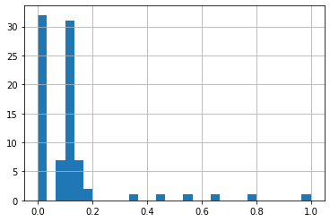

```python
azdias.isnull().mean().hist(bins = 30)
plt.show()
```

The majority of columns seem to have missing values but in the range of 0-20%. But some columns have up to 100% missing values. Let's have a look at those columns and plot columns that contain more than 20% missing data.

```
Columns with more than 20.0% missing values:
AGER_TYP        0.769554
GEBURTSJAHR     0.440203
TITEL_KZ        0.997576
ALTER_HH        0.348137
KK_KUNDENTYP    0.655967
KBA05_BAUMAX    0.534687
dtype: float64
```

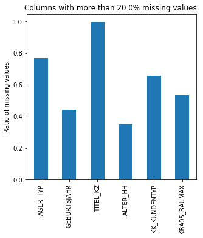

```
The dataset contains 6 columns with more than 20.0% missing values
```

```python
# Perform an assessment of how much missing data there is in each column of the
# dataset.
thresh = 0.20

azdias_null = azdias.isnull().mean()
azdias_null = azdias_null[azdias_null > thresh]
print(f"Columns with more than {thresh * 100}% missing values:")
print(azdias_null)

#plot bar chart with ratio of nan values
fig = plt.figure(figsize = (5,5))
azdias_null.plot(kind = 'bar')
plt.xticks(ticks = np.arange( len(azdias_null.index)), labels = azdias_null.index)
plt.title(f"Columns with more than {thresh * 100}% missing values:")
plt.ylabel("Ratio of missing values")
plt.show()

print(f"The dataset contains {len(azdias_null.index)} columns with more than {thresh*100}% missing values")
```

**AGER_TYP**

```python
# Investigate patterns in the amount of missing data in each column.
#Lets check some of the most interesting columsn regarding amount of missing data
azdias['AGER_TYP'].value_counts(dropna = False)
```

```
NaN    685843
2.0     98472
1.0     79802
3.0     27104
Name: AGER_TYP, dtype: int64
```

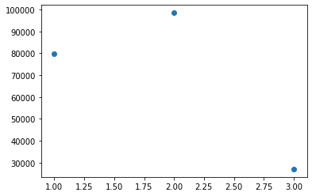

```python
plt.scatter(azdias['AGER_TYP'].value_counts(dropna = False).index, azdias['AGER_TYP'].value_counts(dropna = False).values)
```

```python
azdias.corr()['AGER_TYP'].sort_values()
```

```
ALTERSKATEGORIE_GROB   -0.371805
SEMIO_LUST             -0.263030
KBA05_ANTG1            -0.124865
MOBI_REGIO             -0.121868
PLZ8_ANTG1             -0.120315
                          ...
HEALTH_TYP              0.204686
SEMIO_REL               0.252707
SEMIO_PFLICHT           0.291534
SEMIO_RAT               0.300559
AGER_TYP                1.000000
Name: AGER_TYP, Length: 81, dtype: float64
```

Nearly 80% of data is missing. The correlation with other features seems too low for a really successful imputation. So let's drop it for the moment

```python
azdias.drop('AGER_TYP', axis = 1, inplace = True)
```

**TITEL_KZ**

```python
azdias['TITEL_KZ'].value_counts(dropna = False)
```

```
NaN    889061
1.0      1947
5.0       104
4.0        57
3.0        49
2.0         3
Name: TITEL_KZ, dtype: int64
```

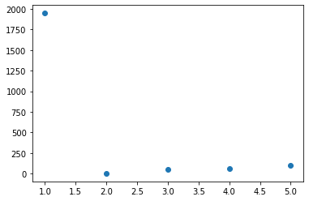

```python
plt.scatter(azdias['TITEL_KZ'].value_counts(dropna = False).index, azdias['TITEL_KZ'].value_counts(dropna = False).values)
plt.show()
```

This feature lists academic titles. The dictionary lists no option for "no title" so it seems that "no title" was coded as unknown. So I think it its save to change NaN values back to 0.

```python
azdias['TITEL_KZ'] = azdias['TITEL_KZ'].replace({np.NaN : 0})
```

**GEBURTSJAHR**

```python
azdias['GEBURTSJAHR'].value_counts(dropna = False)
```

```
NaN       392318
1967.0     11183
1965.0     11090
1966.0     10933
1970.0     10883
           ...
1909.0         7
1904.0         5
1907.0         4
1900.0         4
1902.0         1
Name: GEBURTSJAHR, Length: 117, dtype: int64
```

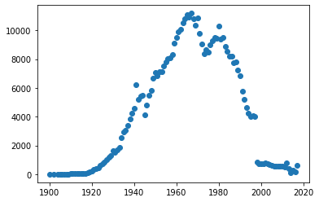

```python
#plot distribution of values in GEBURTSJAHR column
plt.scatter(azdias['GEBURTSJAHR'].value_counts(dropna = False).index, azdias['GEBURTSJAHR'].value_counts(dropna = False).values)
plt.show()
```

```python
years = list(azdias['GEBURTSJAHR'].value_counts(dropna = False).index.sort_values())
missing  = [year  for year in range(1900, 2017) if year not in years ]
missing
```

```
[1901, 1903]
```

```python
azdias.corr()['GEBURTSJAHR'].sort_values()
```

```
FINANZ_VORSORGER        -0.770304
ALTERSKATEGORIE_GROB    -0.633205
FINANZ_MINIMALIST       -0.542958
RETOURTYP_BK_S          -0.541516
SEMIO_LUST              -0.439673
                           ...
FINANZ_UNAUFFAELLIGER    0.741226
ALTER_HH                 0.794150
FINANZ_SPARER            0.868574
PRAEGENDE_JUGENDJAHRE    0.942798
GEBURTSJAHR              1.000000
Name: GEBURTSJAHR, Length: 80, dtype: float64
```

There seems to be data completely distributed over the possible birthyears. So one hypothesis that missing data comes from the loss of certain birthyears is not correct. Additionally there is a high correlation with other features. So let's check other features that contain age data and try to impute this column.

```python
columns_age_person_level = ['ALTERSKATEGORIE_GROB', 'GEBURTSJAHR', 'PRAEGENDE_JUGENDJAHRE']
age_person_features = azdias[columns_age_person_level]
```

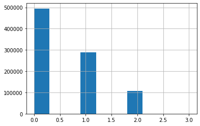

```python
age_person_features.isnull().apply(np.sum, axis = 1).hist()
```

```python
year_youth = azdias[['PRAEGENDE_JUGENDJAHRE', 'GEBURTSJAHR']].groupby('PRAEGENDE_JUGENDJAHRE').mean()
year_youth['PRAEGENDE_JUGENDJAHRE_TEXT'] = year_youth.index.map({1: '40s', 2: '40s', 3:'50s', 4: '50s', 5:'60s', 6:'60s', 7:'60s', 8:'70s', 9:'70s', 10:'80s', 11:'80s', 12:'80s', 13: '80s', 14: '90s', 15 : '90s' })
```

```python
year_youth
```

| PRAEGENDE_JUGENDJAHRE | GEBURTSJAHR | PRAEGENDE_JUGENDJAHRE_TEXT |
| --- | --- | --- |
| 1.0 | 1928.836432 | 40s |
| 2.0 | 1929.199955 | 40s |
| 3.0 | 1940.114285 | 50s |
| 4.0 | 1940.176988 | 50s |
| 5.0 | 1950.003418 | 60s |
| 6.0 | 1949.840242 | 60s |
| 7.0 | 1949.988775 | 60s |
| 8.0 | 1959.858775 | 70s |
| 9.0 | 1959.681830 | 70s |
| 10.0 | 1969.365313 | 80s |
| 11.0 | 1968.963945 | 80s |
| 12.0 | 1969.340070 | 80s |
| 13.0 | 1968.955414 | 80s |
| 14.0 | 1985.573422 | 90s |
| 15.0 | 1986.108686 | 90s |

```python
year_youth_medians = year_youth.groupby(year_youth.index).median()
year_youth_medians
```

| PRAEGENDE_JUGENDJAHRE | GEBURTSJAHR |
| --- | --- |
| 1.0 | 1928.836432 |
| 2.0 | 1929.199955 |
| 3.0 | 1940.114285 |
| 4.0 | 1940.176988 |
| 5.0 | 1950.003418 |
| 6.0 | 1949.840242 |
| 7.0 | 1949.988775 |
| 8.0 | 1959.858775 |
| 9.0 | 1959.681830 |
| 10.0 | 1969.365313 |
| 11.0 | 1968.963945 |
| 12.0 | 1969.340070 |
| 13.0 | 1968.955414 |
| 14.0 | 1985.573422 |
| 15.0 | 1986.108686 |

```python
mapping = year_youth_medians.to_dict()['GEBURTSJAHR']
mapping
```

```
{1.0: 1928.8364315220845,
 2.0: 1929.199954710145,
 3.0: 1940.1142848164907,
 4.0: 1940.1769883435097,
 5.0: 1950.0034182521767,
 6.0: 1949.8402422319948,
 7.0: 1949.9887745556596,
 8.0: 1959.858774921665,
 9.0: 1959.6818295301343,
 10.0: 1969.3653125634448,
 11.0: 1968.9639453125,
 12.0: 1969.3400704740377,
 13.0: 1968.9554140127389,
 14.0: 1985.5734220840654,
 15.0: 1986.108685982029}
```

Now we have got the values that we can use for first imputation of GEBURTSJAHR. Let's try.

```python
def impute_geburtsjahr(row, **kwargs):
    mapping = kwargs['mapping']
    #print('#### new row ####')
    year = row['GEBURTSJAHR']
    youth = row['PRAEGENDE_JUGENDJAHRE']


    #print(year)
    if np.isnan(year) and not np.isnan(youth):
        #impute
        #print("impute!")
        #print("old row:")
        #print(row)
        year = round(mapping[youth])
        #print(year)

    row['GEBURTSJAHR_NEU'] = year
    #print("new row:  ")
    #print(row)
    return row
```

```python
years_imputed = azdias[['GEBURTSJAHR', 'PRAEGENDE_JUGENDJAHRE']].apply(impute_geburtsjahr, axis = 1, mapping = mapping )
```

```python
years_imputed.head(10)
```

|  | GEBURTSJAHR | PRAEGENDE_JUGENDJAHRE | GEBURTSJAHR_NEU |
| --- | --- | --- | --- |
| 0 | NaN | NaN | NaN |
| 1 | 1996.0 | 14.0 | 1996.0 |
| 2 | 1979.0 | 15.0 | 1979.0 |
| 3 | 1957.0 | 8.0 | 1957.0 |
| 4 | 1963.0 | 8.0 | 1963.0 |
| 5 | 1943.0 | 3.0 | 1943.0 |
| 6 | NaN | 10.0 | 1969.0 |
| 7 | 1964.0 | 8.0 | 1964.0 |
| 8 | 1974.0 | 11.0 | 1974.0 |
| 9 | 1975.0 | 15.0 | 1975.0 |

```python
years_imputed.isnull().mean()
```

```
GEBURTSJAHR              0.440203
PRAEGENDE_JUGENDJAHRE    0.121366
GEBURTSJAHR_NEU          0.118742
dtype: float64
```

With this imputation we created a feature with only 12% missing values. So add it to df and drop "GEBURTSJAHR"

```python
azdias = azdias.drop('GEBURTSJAHR', axis = 1)
azdias['GEBURTSJAHR_NEU'] = years_imputed['GEBURTSJAHR_NEU']
azdias.head()
azdias['GEBURTSJAHR_NEU'].isnull().mean()
```

```
0.11874159159176007
```

That looks nice. So I think it is okay that we leave out ALTERSKATEGORIE_GROB for imputation for the moment.

**ALTER_HH**

The next feature on our list with some information regarding age. Missing values <40%.

```python
azdias['ALTER_HH'].value_counts(dropna = False)
```

```
NaN     310267
18.0     60852
17.0     55665
19.0     52890
15.0     51867
16.0     51857
14.0     44275
21.0     41610
20.0     40671
13.0     37612
12.0     34923
10.0     30419
11.0     27924
9.0      22817
8.0      13463
7.0       8419
6.0       3809
5.0       1030
4.0        603
3.0        200
2.0         47
1.0          1
Name: ALTER_HH, dtype: int64
```

```python
azdias.corr()['ALTER_HH'].sort_values()
```

```
FINANZ_VORSORGER        -0.588497
W_KEIT_KIND_HH          -0.525502
ALTERSKATEGORIE_GROB    -0.484652
RETOURTYP_BK_S          -0.446199
SEMIO_LUST              -0.363197
                           ...
FINANZ_ANLEGER           0.556253
FINANZ_SPARER            0.634621
PRAEGENDE_JUGENDJAHRE    0.759810
GEBURTSJAHR_NEU          0.765647
ALTER_HH                 1.000000
Name: ALTER_HH, Length: 80, dtype: float64
```

Let's drop this column. Correlation with GEBURSTJAHR is high.

```python
azdias = azdias.drop('ALTER_HH', axis = 1)
```

**KK_KUNDENTYP**

Nearly 70% missing data.

Consumer pattern over past 12 months

- -1: unknown
- 1: regular customer
- 2: active customer
- 3: new costumer
- 4: stray customer
- 5: inactive customer
- 6: passive customer

```python
azdias['KK_KUNDENTYP'].value_counts(dropna = False)
```

```
NaN    584612
3.0     65151
2.0     62564
5.0     48038
4.0     44512
6.0     44114
1.0     42230
Name: KK_KUNDENTYP, dtype: int64
```

```python
azdias.corr()['KK_KUNDENTYP'].sort_values()
```

```
ONLINE_AFFINITAET     -0.204991
ANZ_PERSONEN          -0.168995
LP_FAMILIE_GROB       -0.150229
LP_FAMILIE_FEIN       -0.147444
LP_LEBENSPHASE_FEIN   -0.140000
                         ...
ZABEOTYP               0.088858
FINANZ_HAUSBAUER       0.100065
RETOURTYP_BK_S         0.102559
W_KEIT_KIND_HH         0.177644
KK_KUNDENTYP           1.000000
Name: KK_KUNDENTYP, Length: 79, dtype: float64
```

Let's drop it. It's tot much missing data.

```python
azdias.drop('KK_KUNDENTYP', axis = 1, inplace = True)
```

**KBA05_BAUMAX**

53% missing

Most common building type within the microcell

- -1: unknown
- 0: unknown
- 1: mainly 1-2 family homes in the microcell
- 2: mainly 3-5 family homes in the microcell
- 3: mainly 6-10 family homes in the microcell
- 4: mainly 10+ family homes in the microcell
- 5: mainly business buildings in the microcell

Should be highly correlated to toher KBA05 features. Let's see:

```python
azdias.corr()['KBA05_BAUMAX'].sort_values()
```

```
KBA05_ANTG1      -0.864638
MOBI_REGIO       -0.829328
KBA05_GBZ        -0.750908
LP_STATUS_FEIN   -0.685585
PLZ8_ANTG1       -0.666403
                    ...
KBA05_ANTG4       0.615578
PLZ8_ANTG3        0.624530
PLZ8_ANTG4        0.656854
PLZ8_BAUMAX       0.667241
KBA05_BAUMAX      1.000000
Name: KBA05_BAUMAX, Length: 78, dtype: float64
```

Shows high correlation with features related to micro- and macro-cell. SO let's drop it.

```python
azdias.drop('KBA05_BAUMAX', axis = 1, inplace = True)
```

```python
# Remove the outlier columns from the dataset. (You'll perform other data
# engineering tasks such as re-encoding and imputation later.)
print("Dropping task already accomplished, see above")
len(azdias.columns)
```

```
Dropping task already accomplished, see above
```

```
81
```

#### Discussion 1.1.2: Assess Missing Data in Each Column

*(Double click this cell and replace this text with your own text, reporting your observations regarding the amount of missing data in each column. Are there any patterns in missing values? Which columns were removed from the dataset?)*

**-> I dropped 4 collums and imputed 2**

#### Step 1.1.3: Assess Missing Data in Each Row

Now, you'll perform a similar assessment for the rows of the dataset. How much data is missing in each row? As with the columns, you should see some groups of points that have a very different numbers of missing values. **Divide the data into two subsets**: one for data points that are above some threshold for missing values, and a second subset for points below that threshold.

In order to know what to do with the outlier rows, we should see if the **distribution of data values** on columns that are not missing data (or are missing very little data) are similar or different between the two groups. Select at least five of these columns and compare the distribution of values.

- You can use seaborn's [`countplot()`](https://seaborn.pydata.org/generated/seaborn.countplot.html) function to create a bar chart of code frequencies and matplotlib's [`subplot()`](https://matplotlib.org/api/_as_gen/matplotlib.pyplot.subplot.html) function to put bar charts for the two subplots side by side.
- To reduce repeated code, you might want to write a function that can perform this comparison, taking as one of its arguments a column to be compared.

Depending on what you observe in your comparison, this will have implications on how you approach your conclusions later in the analysis. If the distributions of non-missing features look similar between the data with many missing values and the data with few or no missing values, then we could argue that simply dropping those points from the analysis won't present a major issue. On the other hand, **if the data with many missing values looks very different from the data with few or no missing values, then we should make a note on those data as special**. We'll revisit these data later on. **Either way, you should continue your analysis for now using just the subset of the data with few or no missing values.**

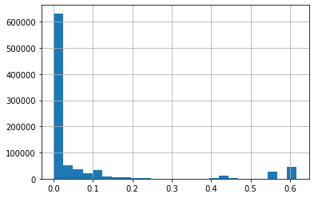

```python
# How much data is missing in each row of the dataset?
azdias.isnull().mean(axis = 1).hist(bins = 25)
plt.show()
```

Distribution of number of missing values in rows looks similar to distribution in columns. Dataset contains high number of rows with only 0-15% missing values but also rows with >40% missing values.

```python
# Write code to divide the data into two subsets based on the number of missing
# values in each row.
tresh_rows = 0.20
azdias_low_missing = azdias.loc[azdias.isnull().mean(axis = 1) <= thresh, :]
azdias_high_missing = azdias.loc[azdias.isnull().mean(axis = 1) > thresh, :]
print(f"{azdias_low_missing.shape[0]} rows in dataset with low_missing rows")
print(f"{azdias_high_missing.shape[0]} rows in dataset with high_missing rows")
print(f"{round(azdias_high_missing.shape[0] * 100/ azdias.shape[0])}% of rows will be discarded later")
```

```
794357 rows in dataset with low_missing rows
96864 rows in dataset with high_missing rows
11% of rows will be discarded later
```

```python
# Compare the distribution of values for at least five columns where there are
# no or few missing values, between the two subsets.

#get n random columns with low or few missing values
n_columns = 5
list_few_columns_all = azdias.loc[:, azdias.isnull().mean() < 0.05].columns
list_few_columns_random = [list_few_columns_all[n] for n in np.random.randint(len(list_few_columns_all), size = n_columns)]
list_few_columns_random
```

```
['SEMIO_MAT', 'LP_STATUS_GROB', 'SEMIO_SOZ', 'TITEL_KZ', 'FINANZ_VORSORGER']
```

```python
azdias_low_missing.loc[:, list_few_columns_random]
```

|  | SEMIO_MAT | LP_STATUS_GROB | SEMIO_SOZ | TITEL_KZ | FINANZ_VORSORGER |
| --- | --- | --- | --- | --- | --- |
| 1 | 3 | 1.0 | 5 | 0.0 | 2 |
| 2 | 3 | 2.0 | 4 | 0.0 | 1 |
| 3 | 1 | 4.0 | 5 | 0.0 | 5 |
| 4 | 2 | 2.0 | 6 | 0.0 | 4 |
| 5 | 4 | 2.0 | 2 | 0.0 | 5 |
| ... | ... | ... | ... | ... | ... |
| 891216 | 3 | 1.0 | 2 | 0.0 | 2 |
| 891217 | 5 | 1.0 | 4 | 0.0 | 3 |
| 891218 | 3 | 2.0 | 5 | 0.0 | 2 |
| 891219 | 5 | 1.0 | 7 | 0.0 | 3 |
| 891220 | 4 | 1.0 | 6 | 0.0 | 5 |

794357 rows × 5 columns

```python
azdias_high_missing.loc[:, list_few_columns_random]
```

|  | SEMIO_MAT | LP_STATUS_GROB | SEMIO_SOZ | TITEL_KZ | FINANZ_VORSORGER |
| --- | --- | --- | --- | --- | --- |
| 0 | 5 | 1.0 | 2 | 0.0 | 3 |
| 11 | 5 | 2.0 | 2 | 0.0 | 3 |
| 14 | 5 | 2.0 | 2 | 0.0 | 3 |
| 17 | 5 | 2.0 | 2 | 0.0 | 3 |
| 24 | 5 | 2.0 | 2 | 0.0 | 3 |
| ... | ... | ... | ... | ... | ... |
| 891171 | 2 | 2.0 | 2 | 0.0 | 3 |
| 891173 | 6 | 2.0 | 3 | 0.0 | 5 |
| 891175 | 5 | 2.0 | 2 | 0.0 | 3 |
| 891185 | 5 | 2.0 | 2 | 0.0 | 3 |
| 891187 | 5 | 2.0 | 2 | 0.0 | 3 |

96864 rows × 5 columns

```python
azdias_high_missing.loc[:, list_few_columns_random]
```

|  | SEMIO_MAT | LP_STATUS_GROB | SEMIO_SOZ | TITEL_KZ | FINANZ_VORSORGER |
| --- | --- | --- | --- | --- | --- |
| 0 | 5 | 1.0 | 2 | 0.0 | 3 |
| 11 | 5 | 2.0 | 2 | 0.0 | 3 |
| 14 | 5 | 2.0 | 2 | 0.0 | 3 |
| 17 | 5 | 2.0 | 2 | 0.0 | 3 |
| 24 | 5 | 2.0 | 2 | 0.0 | 3 |
| ... | ... | ... | ... | ... | ... |
| 891171 | 2 | 2.0 | 2 | 0.0 | 3 |
| 891173 | 6 | 2.0 | 3 | 0.0 | 5 |
| 891175 | 5 | 2.0 | 2 | 0.0 | 3 |
| 891185 | 5 | 2.0 | 2 | 0.0 | 3 |
| 891187 | 5 | 2.0 | 2 | 0.0 | 3 |

96864 rows × 5 columns

```python
#columns from both sets side by side
def compare_columns_vis(df_high, df_low, column_name):
    fig, axes = plt.subplots(1,2 ,figsize = (15,8), sharey = True)


    axes[0].set_title("low missing group")
    sns.countplot(df_low.loc[:, column_name], ax= axes[0])



    axes[1].set_title("high missing group")
    sns.countplot(df_high.loc[:, column_name], ax= axes[1])



    fig.subplots_adjust( hspace=0.4, wspace=0.4)
    fig.suptitle(f"Value distribution in column {column_name} with few missing values in two datasets that represent rows with few and high number of missing values.", fontsize=16, fontweight = 'bold')
    plt.show()

    print(f"low missing group: {df_low.loc[:, column_name].isnull().mean()*100:.1f}% missing values in column")
    print(f"high missing group: {df_high.loc[:, column_name].isnull().mean()*100:.1f}% missing values in column")

    return None
```

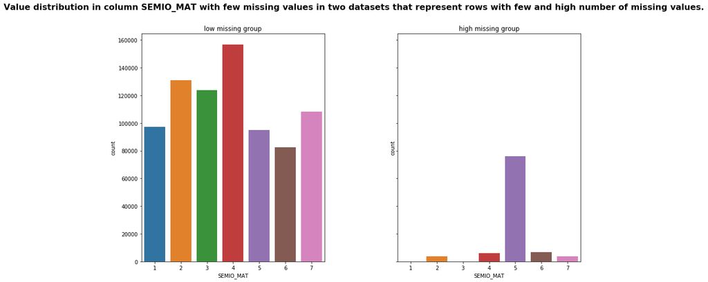

```
low missing group: 0.0% missing values in column
high missing group: 0.0% missing values in column
```

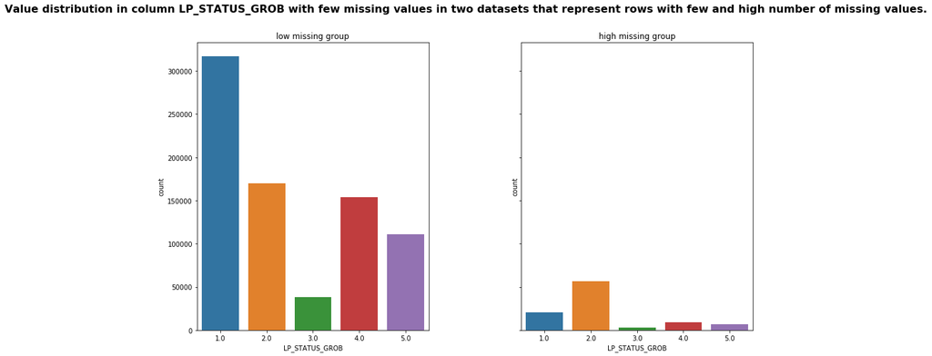

```
low missing group: 0.6% missing values in column
high missing group: 0.4% missing values in column
```

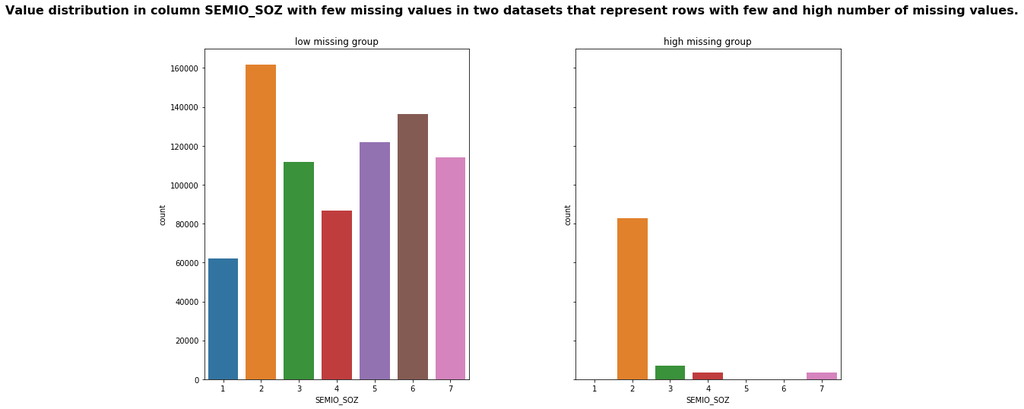

```
low missing group: 0.0% missing values in column
high missing group: 0.0% missing values in column
```

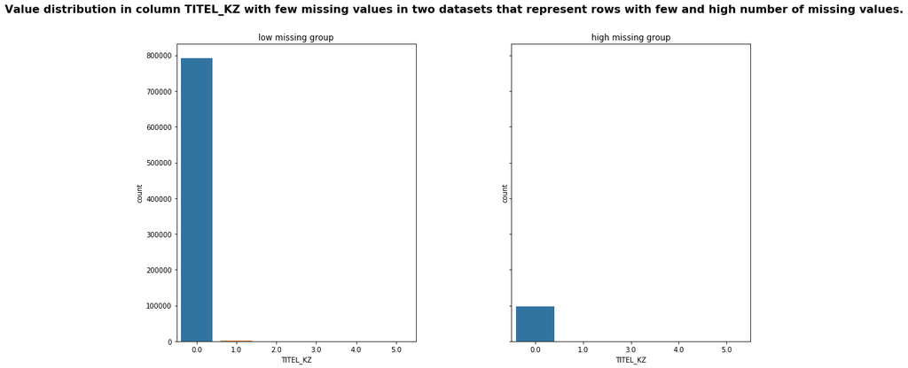

```
low missing group: 0.0% missing values in column
high missing group: 0.0% missing values in column
```

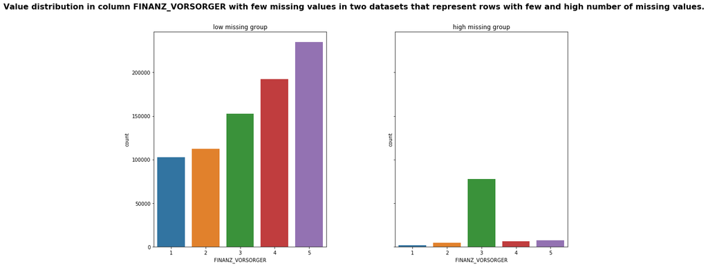

```
low missing group: 0.0% missing values in column
high missing group: 0.0% missing values in column
```

```python
for n in range(n_columns):
    compare_columns_vis(azdias_high_missing, azdias_low_missing, list_few_columns_random[n])
```

```python
#continue now only with a dataset containing only rows with few missing data
azdias = azdias_low_missing
```

#### Discussion 1.1.3: Assess Missing Data in Each Row

*(Double-click this cell and replace this text with your own text, reporting your observations regarding missing data in rows. Are the data with lots of missing values are qualitatively different from data with few or no missing values?)*

So there seems to be something special about rows with high number of missing values. Let's check that later and continue with dataset containing rows with few missing data accroding threshold.

### Step 1.2: Select and Re-Encode Features

Checking for missing data isn't the only way in which you can prepare a dataset for analysis. Since the unsupervised learning techniques to be used will only work on data that is encoded numerically, you need to make a few encoding changes or additional assumptions to be able to make progress. In addition, while almost all of the values in the dataset are encoded using numbers, not all of them represent numeric values. Check the third column of the feature summary (`feat_info`) for a summary of types of measurement.

- For **numeric and interval data**, these features can be **kept without changes**.
- Most of the variables in the dataset are **ordinal** in nature. While ordinal values may technically be non-linear in spacing, make the **simplifying assumption that the ordinal variables can be treated as being interval in nature** (that is, kept without any changes).
- Special handling may be necessary for the remaining two variable types: **categorical, and 'mixed**'.

In the first two parts of this sub-step, you will perform an investigation of the categorical and mixed-type features and **make a decision on each of them**, whether you will keep, drop, or re-encode each. Then, in the last part, you will create a new data frame with only the selected and engineered columns.

Data wrangling is often the trickiest part of the data analysis process, and there's a lot of it to be done here. But stick with it: once you're done with this step, you'll be ready to get to the machine learning parts of the project!

```python
# How many features are there of each data type?
feat_info[feat_info.columns[2]].value_counts()
```

```
ordinal        49
categorical    21
mixed           7
numeric         7
interval        1
Name: type, dtype: int64
```

```python
azdias.dtypes.value_counts()
```

```
float64    53
int64      24
object      4
dtype: int64
```

```python
azdias.loc[:,azdias.dtypes == 'object']
```

|  | OST_WEST_KZ | CAMEO_DEUG_2015 | CAMEO_DEU_2015 | CAMEO_INTL_2015 |
| --- | --- | --- | --- | --- |
| 1 | W | 8 | 8A | 51 |
| 2 | W | 4 | 4C | 24 |
| 3 | W | 2 | 2A | 12 |
| 4 | W | 6 | 6B | 43 |
| 5 | W | 8 | 8C | 54 |
| ... | ... | ... | ... | ... |
| 891216 | W | 7 | 7A | 41 |
| 891217 | W | 9 | 9D | 51 |
| 891218 | W | 4 | 4C | 24 |
| 891219 | W | 9 | 9D | 51 |
| 891220 | W | 6 | 6B | 43 |

794357 rows × 4 columns

#### Step 1.2.1: Re-Encode Categorical Features

For categorical data, you would ordinarily need to encode the levels as dummy variables. Depending on the number of categories, perform one of the following:

- For **binary (two-level) categoricals that take numeric** values, you can **keep** them without needing to do anything.
- There is **one binary variable that takes on non-numeric** values. For this one, you need to **re-encode** the values as numbers or create a dummy variable.
- For **multi-level categoricals** (three or more values), you can choose to encode the values using multiple **dummy variables** (e.g. via [OneHotEncoder](http://scikit-learn.org/stable/modules/generated/sklearn.preprocessing.OneHotEncoder.html)), or (to keep things straightforward) just drop them from the analysis. As always, document your choices in the Discussion section.

```python
# Assess categorical variables: which are binary, which are multi-level, and
# which one needs to be re-encoded?
categorical_columns = feat_info[feat_info['type'] == 'categorical']['attribute'].values
print(categorical_columns)
```

```
['AGER_TYP' 'ANREDE_KZ' 'CJT_GESAMTTYP' 'FINANZTYP' 'GFK_URLAUBERTYP'
 'GREEN_AVANTGARDE' 'LP_FAMILIE_FEIN' 'LP_FAMILIE_GROB' 'LP_STATUS_FEIN'
 'LP_STATUS_GROB' 'NATIONALITAET_KZ' 'SHOPPER_TYP' 'SOHO_KZ' 'TITEL_KZ'
 'VERS_TYP' 'ZABEOTYP' 'KK_KUNDENTYP' 'GEBAEUDETYP' 'OST_WEST_KZ'
 'CAMEO_DEUG_2015' 'CAMEO_DEU_2015']
```

```
<function matplotlib.pyplot.show(*args, **kw)>
```

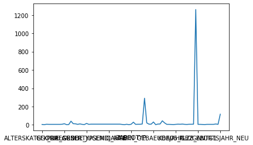

```python
column_uniques = azdias.apply(lambda column: column.nunique(), axis = 0)
column_uniques.plot()
plt.show
```

```python
# Re-encode categorical variable(s) to be kept in the analysis.
binary = column_uniques[column_uniques == 2]
print("binary columns:")
print(binary)

for column in azdias.loc[:,binary.index]:
    print(azdias.loc[:, column].unique())
```

```
binary columns:
ANREDE_KZ           2
GREEN_AVANTGARDE    2
SOHO_KZ             2
VERS_TYP            2
OST_WEST_KZ         2
dtype: int64
[2 1]
[0 1]
[1. 0.]
[ 2.  1. nan]
['W' 'O']
```

OST_WEST_KZ seems to be the column that has to be converted to binary numeric values ['W', 'O'] -> [1,0]

```python
print(azdias['OST_WEST_KZ'].unique())
#print(azdias['OST_WEST_KZ'].map({'O': 0, 'W':1}))
azdias['OST_WEST_KZ'] = azdias['OST_WEST_KZ'].map({'O': 0, 'W':1})
print(azdias['OST_WEST_KZ'].unique())
```

```
['W' 'O']
[1 0]
```

```python
#now reencode other (non-binary categoricals)
#delete the column names that we already deleted by dropping columns with missing values
categorical_columns = [column  for column in categorical_columns if column in azdias.columns]
dummies = pd.get_dummies(azdias[categorical_columns].astype('category'))
print(f"{len(list(dummies.columns))} new columns were created by using one-hot encoding")
azdias = pd.concat([azdias, dummies], axis = 1)
```

```
144 new columns were created by using one-hot encoding
```

```python
azdias.info()
```

```
<class 'pandas.core.frame.DataFrame'>
Int64Index: 794357 entries, 1 to 891220
Columns: 225 entries, ALTERSKATEGORIE_GROB to CAMEO_DEU_2015_9E
dtypes: float64(53), int64(25), object(3), uint8(144)
memory usage: 626.0+ MB
```

```python
azdias.columns
```

```
Index(['ALTERSKATEGORIE_GROB', 'ANREDE_KZ', 'CJT_GESAMTTYP',
       'FINANZ_MINIMALIST', 'FINANZ_SPARER', 'FINANZ_VORSORGER',
       'FINANZ_ANLEGER', 'FINANZ_UNAUFFAELLIGER', 'FINANZ_HAUSBAUER',
       'FINANZTYP',
       ...
       'CAMEO_DEU_2015_7E', 'CAMEO_DEU_2015_8A', 'CAMEO_DEU_2015_8B',
       'CAMEO_DEU_2015_8C', 'CAMEO_DEU_2015_8D', 'CAMEO_DEU_2015_9A',
       'CAMEO_DEU_2015_9B', 'CAMEO_DEU_2015_9C', 'CAMEO_DEU_2015_9D',
       'CAMEO_DEU_2015_9E'],
      dtype='object', length=225)
```

```python
#drop old-non-encoded columns
azdias.drop(categorical_columns, axis = 1, inplace= True)
```

```python
azdias.info()
```

```
<class 'pandas.core.frame.DataFrame'>
Int64Index: 794357 entries, 1 to 891220
Columns: 206 entries, ALTERSKATEGORIE_GROB to CAMEO_DEU_2015_9E
dtypes: float64(41), int64(20), object(1), uint8(144)
memory usage: 510.9+ MB
```

```python
azdias.loc[:,azdias.dtypes == 'object']
```

|  | CAMEO_INTL_2015 |
| --- | --- |
| 1 | 51 |
| 2 | 24 |
| 3 | 12 |
| 4 | 43 |
| 5 | 54 |
| ... | ... |
| 891216 | 41 |
| 891217 | 51 |
| 891218 | 24 |
| 891219 | 51 |
| 891220 | 43 |

794357 rows × 1 columns

```python
#convert CAMEO_INTL_2015 to float
azdias['CAMEO_INTL_2015'] = azdias['CAMEO_INTL_2015'].astype('float64')
```

#### Discussion 1.2.1: Re-Encode Categorical Features

(Double-click this cell and replace this text with your own text, reporting your findings and decisions regarding categorical features. Which ones did you keep, which did you drop, and what engineering steps did you perform?)

I used the type from the feature_summary file to decide which columns to re-encode. As a first step I transformed the only binary categorical column OST_WEST_KZ to values 0 and 1 encoding the categories 'O' and 'W'. Then I grabbed the other 'categorical' columns from th dataset and applied one-hot encoding to it. So I don't have to drop a single column. The dummy columns added 144 new features to the dataset.

#### Step 1.2.2: Engineer Mixed-Type Features

There are a handful of features that are marked as **"mixed"** in the feature summary that require special treatment in order to be included in the analysis. There are two in particular that deserve attention; the handling of the rest are up to your own choices:

- **"PRAEGENDE_JUGENDJAHRE"** combines information on three dimensions: generation by decade, movement (mainstream vs. avantgarde), and nation (east vs. west). While there aren't enough levels to disentangle east from west, you should create two new variables to capture the other two dimensions: an **interval-type variable for decade, and a binary variable for movement**.
- **"CAMEO_INTL_2015"** combines information on two axes: wealth and life stage. Break up the two-digit codes by their 'tens'-place and 'ones'-place digits into **two new ordinal variables** (which, for the purposes of this project, is equivalent to just treating them as their raw numeric values).
- If **you decide to keep or engineer new features around the other mixed-type features**, make sure you note your steps in the Discussion section.

Be sure to check `Data_Dictionary.md` for the details needed to finish these tasks.

```python
#get all mixed columns remaining in azdias
mixed_columns = feat_info[feat_info['type'] == 'mixed']['attribute'].values
mixed_columns = [column  for column in mixed_columns if column in azdias.columns]
feat_info[feat_info['type'] == 'mixed']
```

|  | attribute | information_level | type | missing_or_unknown |
| --- | --- | --- | --- | --- |
| 15 | LP_LEBENSPHASE_FEIN | person | mixed | [0] |
| 16 | LP_LEBENSPHASE_GROB | person | mixed | [0] |
| 22 | PRAEGENDE_JUGENDJAHRE | person | mixed | [-1,0] |
| 56 | WOHNLAGE | building | mixed | [-1] |
| 59 | CAMEO_INTL_2015 | microcell_rr4 | mixed | [-1,XX] |
| 64 | KBA05_BAUMAX | microcell_rr3 | mixed | [-1,0] |
| 79 | PLZ8_BAUMAX | macrocell_plz8 | mixed | [-1,0] |

```python
# Investigate "PRAEGENDE_JUGENDJAHRE" and engineer two new variables.
azdias['PRAEGENDE_JUGENDJAHRE'].unique()
```

```
array([14., 15.,  8.,  3., 10., 11.,  5.,  9.,  6.,  4., nan,  2.,  1.,
       12., 13.,  7.])
```

PRAEGENDE_JUGENDJAHRE Dominating movement of person's youth (avantgarde vs. mainstream; east vs. west)

- -1: unknown
- 0: unknown
- 1: 40s - war years (Mainstream, E+W)
- 2: 40s - reconstruction years (Avantgarde, E+W)
- 3: 50s - economic miracle (Mainstream, E+W)
- 4: 50s - milk bar / Individualisation (Avantgarde, E+W)
- 5: 60s - economic miracle (Mainstream, E+W)
- 6: 60s - generation 68 / student protestors (Avantgarde, W)
- 7: 60s - opponents to the building of the Wall (Avantgarde, E)
- 8: 70s - family orientation (Mainstream, E+W)
- 9: 70s - peace movement (Avantgarde, E+W)
- 10: 80s - Generation Golf (Mainstream, W)
- 11: 80s - ecological awareness (Avantgarde, W)
- 12: 80s - FDJ / communist party youth organisation (Mainstream, E)
- 13: 80s - Swords into ploughshares (Avantgarde, E)
- 14: 90s - digital media kids (Mainstream, E+W)
- 15: 90s - ecological awareness (Avantgarde, E+W)

We'd like to extract an interval-type variable for decade (X0s), and a binary variable for movement (Mainstream/Avantgarde). Build manually a dict for mapping with help of Data_Dictionary data.

```python
# map to interval 40s : 0, 50s : 1, 60s : 2, 70s: 3, 80s: 4, 90s : 5
jugend_decade = {1 : '0', 2 : '0', 3 : '1', 4 : '1', 5 : '2', 6 : '2', 7 : '2',
                 8 : '3', 9 : '3', 10 : '4', 11 : '4', 12 : '4', 13 : '4',
                 14 : '5', 15 : '5'}

# map binary mainstream : 0, avantgarde : 1
jugend_movement = {1 : '0', 2 : '1', 3 : '0', 4 : '1', 5 : '0', 6 : '1',
                   7 : '1', 8 : '0', 9 : '1', 10 : '0', 11 : '1', 12 : '0',
                   13 : '1', 14 : '0', 15 : '1'}
```

```python
#lets map it
azdias['PRAEGENDE_JUGENDJAHRE_DECADE'] = azdias['PRAEGENDE_JUGENDJAHRE'].map(jugend_decade).astype('float64')
print(azdias['PRAEGENDE_JUGENDJAHRE_DECADE'].unique())
azdias['PRAEGENDE_JUGENDJAHRE_MOVEMENT'] = azdias['PRAEGENDE_JUGENDJAHRE'].map(jugend_movement).astype('float64')
azdias['PRAEGENDE_JUGENDJAHRE_MOVEMENT'].unique()
```

```
[ 5.  3.  1.  4.  2. nan  0.]
```

```
array([ 0.,  1., nan])
```

```python
# Investigate "CAMEO_INTL_2015" and engineer two new variables.
azdias['CAMEO_INTL_2015'].unique()
```

```
array([51., 24., 12., 43., 54., 22., 14., 13., 15., 33., 41., 34., 55.,
       25., nan, 23., 31., 52., 35., 45., 44., 32.])
```

CAMEO_INTL_2015 German CAMEO: Wealth / Life Stage Typology, mapped to international code

- -1: unknown
- 11: Wealthy Households - Pre-Family Couples & Singles
- 12: Wealthy Households - Young Couples With Children
- 13: Wealthy Households - Families With School Age Children
- 14: Wealthy Households - Older Families & Mature Couples
- 15: Wealthy Households - Elders In Retirement
- 21: Prosperous Households - Pre-Family Couples & Singles
- 22: Prosperous Households - Young Couples With Children
- 23: Prosperous Households - Families With School Age Children
- 24: Prosperous Households - Older Families & Mature Couples
- 25: Prosperous Households - Elders In Retirement
- 31: Comfortable Households - Pre-Family Couples & Singles
- 32: Comfortable Households - Young Couples With Children
- 33: Comfortable Households - Families With School Age Children
- 34: Comfortable Households - Older Families & Mature Couples
- 35: Comfortable Households - Elders In Retirement
- 41: Less Affluent Households - Pre-Family Couples & Singles
- 42: Less Affluent Households - Young Couples With Children
- 43: Less Affluent Households - Families With School Age Children
- 44: Less Affluent Households - Older Families & Mature Couples
- 45: Less Affluent Households - Elders In Retirement
- 51: Poorer Households - Pre-Family Couples & Singles
- 52: Poorer Households - Young Couples With Children
- 53: Poorer Households - Families With School Age Children
- 54: Poorer Households - Older Families & Mature Couples
- 55: Poorer Households - Elders In Retirement
- XX: unknown

We'd like to extract wealth and life stage by breaking up the two-digit codes by their 'tens'-place (**wealth of household**) and 'ones'-place (**family life stage**) digits into two new ordinal variables.

```python
azdias['CAMEO_INTL_2015_WEALTH'] = azdias['CAMEO_INTL_2015'].astype('float64').apply(lambda x :  np.NaN if x == np.NaN else x//10)
azdias['CAMEO_INTL_2015_LIFE_STAGE'] = azdias['CAMEO_INTL_2015'].astype('float64').apply(lambda x :  np.NaN if x == np.NaN else x%10)
```

```python
azdias[['CAMEO_INTL_2015_WEALTH', 'CAMEO_INTL_2015_LIFE_STAGE']].describe()
```

|  | CAMEO_INTL_2015_WEALTH | CAMEO_INTL_2015_LIFE_STAGE |
| --- | --- | --- |
| count | 790011.000000 | 790011.000000 |
| mean | 3.263182 | 2.872816 |
| std | 1.464657 | 1.485005 |
| min | 1.000000 | 1.000000 |
| 25% | 2.000000 | 1.000000 |
| 50% | 4.000000 | 3.000000 |
| 75% | 5.000000 | 4.000000 |
| max | 5.000000 | 5.000000 |

All the other 'mixed' columns including the both I used to extract the new features will be dropped.

```python
azdias.drop(mixed_columns, axis = 1, inplace = True)
azdias.info()
```

```
<class 'pandas.core.frame.DataFrame'>
Int64Index: 794357 entries, 1 to 891220
Columns: 204 entries, ALTERSKATEGORIE_GROB to CAMEO_INTL_2015_LIFE_STAGE
dtypes: float64(40), int64(20), uint8(144)
memory usage: 498.8 MB
```

So now we have no more object type columns left. All columns contain numeric values.

#### Discussion 1.2.2: Engineer Mixed-Type Features

(Double-click this cell and replace this text with your own text, reporting your findings and decisions regarding mixed-value features. Which ones did you keep, which did you drop, and what engineering steps did you perform?)

**Category columns**

- The category columns were all óne-hot encoded to dummy variables

**Mixed-type columns**

#### Step 1.2.3: Complete Feature Selection

In order to finish this step up, you need to make sure that your data frame now only has the columns that you want to keep. To summarize, the **dataframe should consist of the following**:

- All numeric, interval, and ordinal type columns from the original dataset.
- Binary categorical features (all numerically-encoded).
- Engineered features from other multi-level categorical features and mixed features.

Make sure that for any new columns that you have engineered, that you've excluded the original columns from the final dataset. Otherwise, their values will interfere with the analysis later on the project. For example, you should not keep "PRAEGENDE_JUGENDJAHRE", since its values won't be useful for the algorithm: only the values derived from it in the engineered features you created should be retained. As a reminder, your data should only be from **the subset with few or no missing values**.

```python
# If there are other re-engineering tasks you need to perform, make sure you
# take care of them here. (Dealing with missing data will come in step 2.1.)
```

```python
# Do whatever you need to in order to ensure that the dataframe only contains
# the columns that should be passed to the algorithm functions.

#check datatypes of dataframe
azdias.info()
```

```
<class 'pandas.core.frame.DataFrame'>
Int64Index: 794357 entries, 1 to 891220
Columns: 204 entries, ALTERSKATEGORIE_GROB to CAMEO_INTL_2015_LIFE_STAGE
dtypes: float64(40), int64(20), uint8(144)
memory usage: 498.8 MB
```

### Step 1.3: Create a Cleaning Function

Even though you've finished cleaning up the general population demographics data, it's important to look ahead to the future and realize that **you'll need to perform the same cleaning steps on the customer demographics data**. In this substep, complete the function below to execute the main feature selection, encoding, and re-engineering steps you performed above. Then, when it comes to looking at the customer data in Step 3, you can just run this function on that DataFrame to get the trimmed dataset in a single step.

```python
def clean_data(df):
    """
    Perform feature trimming, re-encoding, and engineering for demographics
    data

    INPUT: Demographics DataFrame
    OUTPUT: Trimmed and cleaned demographics DataFrame
    """

    # Put in code here to execute all main cleaning steps:
    # convert missing value codes into NaNs, ...
    #create a mapping dict {columnname : [codes]}
    missing_dict = feat_info[['attribute', 'missing_or_unknown']].set_index('attribute').to_dict()['missing_or_unknown']
    #convert list strings to real list
    missing_dict_lists = {key : value.replace('[', '').replace(']', '').split(',') \
                          if value != '[]' else list() for key, value in missing_dict.items()}

    df = df.apply(map_missing, axis = 0, dict = missing_dict_lists)


    # remove selected columns and rows, ...
    #columns first
    #AGER_TYP
    df.drop('AGER_TYP', axis = 1, inplace = True)
    #TITEL_KZ
    df['TITEL_KZ'] = df['TITEL_KZ'].replace({np.NaN : 0})
    #GEBURTSJAHR
    year_youth = df[['PRAEGENDE_JUGENDJAHRE', 'GEBURTSJAHR']].groupby('PRAEGENDE_JUGENDJAHRE').mean()
    year_youth['PRAEGENDE_JUGENDJAHRE_TEXT'] = year_youth.index.map({1: '40s', 2: '40s', 3:'50s', 4: '50s', 5:'60s', 6:'60s', 7:'60s', 8:'70s', 9:'70s', 10:'80s', 11:'80s', 12:'80s', 13: '80s', 14: '90s', 15 : '90s' })
    year_youth_medians = year_youth.groupby(year_youth.index).median()
    mapping = year_youth_medians.to_dict()['GEBURTSJAHR']
    years_imputed = df[['GEBURTSJAHR', 'PRAEGENDE_JUGENDJAHRE']].apply(impute_geburtsjahr, axis = 1, mapping = mapping )
    df = df.drop('GEBURTSJAHR', axis = 1)
    df['GEBURTSJAHR_NEU'] = years_imputed['GEBURTSJAHR_NEU']
    df.head()
    df['GEBURTSJAHR_NEU'].isnull().mean()
    #ALTER_HH
    df = df.drop('ALTER_HH', axis = 1)
    #KK_KUNDENTYP
    df.drop('KK_KUNDENTYP', axis = 1, inplace = True)
    #KBA05_BAUMAX
    df.drop('KBA05_BAUMAX', axis = 1, inplace = True)

    #now rows
    tresh_rows = 0.20
    df_low_missing = df.loc[df.isnull().mean(axis = 1) <= thresh, :]
    df_high_missing = df.loc[df.isnull().mean(axis = 1) > thresh, :]
    df = df_low_missing.copy()


    # select, re-encode, and engineer column values.
    categorical_columns = feat_info[feat_info['type'] == 'categorical']['attribute'].values
    #binary OST_WEST
    df['OST_WEST_KZ'] = df['OST_WEST_KZ'].map({'O': 0, 'W':1})
    #dummies
    categorical_columns = [column  for column in categorical_columns if column in df.columns]
    dummies = pd.get_dummies(df[categorical_columns].astype('category'))
    df = pd.concat([df, dummies], axis = 1)
    df.drop(categorical_columns, axis = 1, inplace= True)
    df['CAMEO_INTL_2015'] = df['CAMEO_INTL_2015'].astype('float64')

    #mixed
    jugend_decade = {1 : '0', 2 : '0', 3 : '1', 4 : '1', 5 : '2', 6 : '2', 7 : '2',
                     8 : '3', 9 : '3', 10 : '4', 11 : '4', 12 : '4', 13 : '4',
                     14 : '5', 15 : '5'}
    jugend_movement = {1 : '0', 2 : '1', 3 : '0', 4 : '1', 5 : '0', 6 : '1',
                       7 : '1', 8 : '0', 9 : '1', 10 : '0', 11 : '1', 12 : '0',
                       13 : '1', 14 : '0', 15 : '1'}
    df['PRAEGENDE_JUGENDJAHRE_DECADE'] = df['PRAEGENDE_JUGENDJAHRE'].map(jugend_decade).astype('float64')
    df['PRAEGENDE_JUGENDJAHRE_MOVEMENT'] = df['PRAEGENDE_JUGENDJAHRE'].map(jugend_movement).astype('float64')
    df['CAMEO_INTL_2015_WEALTH'] = df['CAMEO_INTL_2015'].astype('float64').apply(lambda x :  np.NaN if x == np.NaN else x//10)
    df['CAMEO_INTL_2015_LIFE_STAGE'] = df['CAMEO_INTL_2015'].astype('float64').apply(lambda x :  np.NaN if x == np.NaN else x%10)
    df.drop(mixed_columns, axis = 1, inplace = True)

    #drop rows with missing data

    df = df.dropna(axis = 0)

    # Return the cleaned dataframe.
    return df, df_high_missing
```

## Step 2: Feature Transformation

### Step 2.1: Apply Feature Scaling

Before we apply dimensionality reduction techniques to the data, we need to perform feature scaling so that the principal component vectors are not influenced by the natural differences in scale for features. Starting from this part of the project, you'll want to keep an eye on the [API reference page for sklearn](http://scikit-learn.org/stable/modules/classes.html) to help you navigate to all of the classes and functions that you'll need. In this substep, you'll need to check the following:

- sklearn requires that data not have missing values in order for its estimators to work properly. So, before applying the scaler to your data, **make sure that you've cleaned the DataFrame of the remaining missing values**. This can be as simple as just removing all data points with missing data, or applying an [Imputer](http://scikit-learn.org/stable/modules/generated/sklearn.preprocessing.Imputer.html) to replace all missing values. You might also try a more complicated procedure where you temporarily remove missing values in order to compute the scaling parameters before re-introducing those missing values and applying imputation. Think about how much missing data you have and what possible effects each approach might have on your analysis, and justify your decision in the discussion section below.
- For the actual scaling function, a **[StandardScaler]**(http://scikit-learn.org/stable/modules/generated/sklearn.preprocessing.StandardScaler.html) instance is suggested, scaling each feature to mean 0 and standard deviation 1.
- For these classes, you can make use of the `.fit_transform()` method to both fit a procedure to the data as well as apply the transformation to the data at the same time. Don't forget to **keep the fit sklearn objects handy, since you'll be applying them to the customer demographics data** towards the end of the project.

```python
azdias.info()
```

```
<class 'pandas.core.frame.DataFrame'>
Int64Index: 794357 entries, 1 to 891220
Columns: 204 entries, ALTERSKATEGORIE_GROB to CAMEO_INTL_2015_LIFE_STAGE
dtypes: float64(40), int64(20), uint8(144)
memory usage: 498.8 MB
```

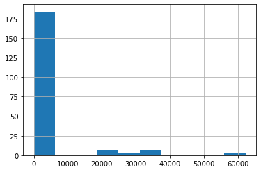

```python
# If you've not yet cleaned the dataset of all NaN values, then investigate and
# do that now.
azdias.isnull().sum().hist()
plt.show()
```

```python
#as a first apporach I drop all rows with NaN values
azdias_clean = azdias.dropna(axis = 0)
azdias_clean.info()
```

```
<class 'pandas.core.frame.DataFrame'>
Int64Index: 623211 entries, 1 to 891220
Columns: 204 entries, ALTERSKATEGORIE_GROB to CAMEO_INTL_2015_LIFE_STAGE
dtypes: float64(40), int64(20), uint8(144)
memory usage: 375.6 MB
```

```python
# Apply feature scaling to the general population demographics data.
scaler = StandardScaler()
scaler.fit(azdias_clean)
azdias_ss = scaler.transform(azdias_clean)
pd.DataFrame(azdias_ss).describe()
```

|  | 0 | 1 | 2 | 3 | 4 | 5 | 6 | 7 | 8 | 9 | ... | 194 | 195 | 196 | 197 | 198 | 199 | 200 | 201 | 202 | 203 |
| --- | --- | --- | --- | --- | --- | --- | --- | --- | --- | --- | --- | --- | --- | --- | --- | --- | --- | --- | --- | --- | --- |
| count | 6.232110e+05 | 6.232110e+05 | 6.232110e+05 | 6.232110e+05 | 6.232110e+05 | 6.232110e+05 | 6.232110e+05 | 6.232110e+05 | 6.232110e+05 | 6.232110e+05 | ... | 6.232110e+05 | 6.232110e+05 | 6.232110e+05 | 6.232110e+05 | 6.232110e+05 | 6.232110e+05 | 6.232110e+05 | 6.232110e+05 | 6.232110e+05 | 6.232110e+05 |
| mean | -5.147811e-15 | 2.094513e-14 | 7.247308e-15 | 1.271063e-14 | 3.197158e-16 | 2.377495e-15 | -4.158460e-15 | 1.247939e-15 | -1.989889e-15 | 8.230481e-15 | ... | 3.026769e-15 | -1.827481e-15 | 6.359858e-15 | -1.680325e-15 | 4.676901e-15 | -4.043326e-15 | 6.540037e-15 | 5.475737e-15 | -9.612782e-16 | -2.986688e-15 |
| std | 1.000001e+00 | 1.000001e+00 | 1.000001e+00 | 1.000001e+00 | 1.000001e+00 | 1.000001e+00 | 1.000001e+00 | 1.000001e+00 | 1.000001e+00 | 1.000001e+00 | ... | 1.000001e+00 | 1.000001e+00 | 1.000001e+00 | 1.000001e+00 | 1.000001e+00 | 1.000001e+00 | 1.000001e+00 | 1.000001e+00 | 1.000001e+00 | 1.000001e+00 |
| min | -1.746287e+00 | -1.512226e+00 | -1.141397e+00 | -1.765054e+00 | -1.221852e+00 | -1.139026e+00 | -1.588887e+00 | -1.591635e+00 | -1.665693e+00 | -1.660645e+00 | ... | -1.574287e-01 | -1.658179e-01 | -1.967730e-01 | -1.850067e-01 | -1.966190e-01 | -7.586111e-02 | -2.280170e+00 | -5.536715e-01 | -1.595951e+00 | -1.251111e+00 |
| 25% | -7.720894e-01 | -7.773505e-01 | -1.141397e+00 | -1.045045e+00 | -1.221852e+00 | -1.139026e+00 | -8.565440e-01 | -2.734945e-01 | -9.781753e-01 | -1.148386e+00 | ... | -1.574287e-01 | -1.658179e-01 | -1.967730e-01 | -1.850067e-01 | -1.966190e-01 | -7.586111e-02 | -9.023201e-01 | -5.536715e-01 | -9.099923e-01 | -1.251111e+00 |
| 50% | 2.021080e-01 | -4.247510e-02 | 2.198318e-01 | 3.949718e-01 | 1.586046e-01 | -4.103252e-01 | -1.242011e-01 | -2.734945e-01 | 3.968602e-01 | -1.238688e-01 | ... | -1.574287e-01 | -1.658179e-01 | -1.967730e-01 | -1.850067e-01 | -1.966190e-01 | -7.586111e-02 | -2.133950e-01 | -5.536715e-01 | 4.619255e-01 | 8.284302e-02 |
| 75% | 1.176305e+00 | 6.924003e-01 | 9.004463e-01 | 1.114980e+00 | 8.488328e-01 | 1.047076e+00 | 6.081418e-01 | 1.044646e+00 | 1.084378e+00 | 9.006488e-01 | ... | -1.574287e-01 | -1.658179e-01 | -1.967730e-01 | -1.850067e-01 | -1.966190e-01 | -7.586111e-02 | 1.164455e+00 | -5.536715e-01 | 1.147884e+00 | 7.498199e-01 |
| max | 1.176305e+00 | 1.427276e+00 | 1.581061e+00 | 1.114980e+00 | 1.539061e+00 | 1.775776e+00 | 1.340485e+00 | 1.044646e+00 | 1.084378e+00 | 1.412908e+00 | ... | 6.352080e+00 | 6.030712e+00 | 5.081997e+00 | 5.405210e+00 | 5.085978e+00 | 1.318198e+01 | 1.164455e+00 | 1.806125e+00 | 1.147884e+00 | 1.416797e+00 |

8 rows × 204 columns

### Discussion 2.1: Apply Feature Scaling

As a first approach I dropped all rows containing missing values (~170.000 rows, 22% of all rows). A StandardScaler was used to scale the remaining data to a mean of 0 and standard deviation of 1.

### Step 2.2: Perform Dimensionality Reduction

On your scaled data, you are now ready to **apply dimensionality reduction techniques**.

- Use sklearn's [PCA](http://scikit-learn.org/stable/modules/generated/sklearn.decomposition.PCA.html) class to apply principal component analysis on the data, thus finding the vectors of maximal variance in the data. To start, you should not set any parameters (so all components are computed) or **set a number of components that is at least half the number of features** (so there's enough features to see the general trend in variability).
- Check out the **ratio of variance explained by each principal component** as well as the **cumulative variance** explained. Try plotting the cumulative or sequential values using matplotlib's [`plot()`](https://matplotlib.org/api/_as_gen/matplotlib.pyplot.plot.html) function. Based on what you find, **select a value for the number of transformed features** you'll retain for the clustering part of the project.
- Once you've made a choice for the number of components to keep, make sure you **re-fit a PCA** instance to perform the decided-on transformation.

```python
# Apply PCA to the data without setting parameters
pca = PCA()
pca.fit_transform(azdias_ss)
```

```
array([[ 5.42592955e+00, -3.43980486e+00, -3.36738889e+00, ...,
         7.54943604e-15, -5.56045191e-15,  3.01714317e-17],
       [-6.39105862e-01, -1.05067491e+00, -3.41338268e+00, ...,
        -2.83853530e-15,  1.27834533e-15, -3.93075153e-16],
       [-3.37459333e-01,  8.07769112e-02,  3.15288515e+00, ...,
        -2.12278120e-15, -1.83950376e-15, -6.36960282e-16],
       ...,
       [ 4.90443915e+00, -2.80170191e+00, -3.48343710e+00, ...,
         1.39296603e-17,  4.67349895e-17,  7.06447670e-18],
       [ 6.87254769e+00, -3.91505277e+00,  2.75133212e+00, ...,
         1.19623931e-16, -5.03516706e-17,  9.48496892e-19],
       [ 2.16721840e-01,  2.73203964e+00,  2.28124397e+00, ...,
         1.99891181e-17,  8.57974948e-18, -1.48789116e-18]])
```

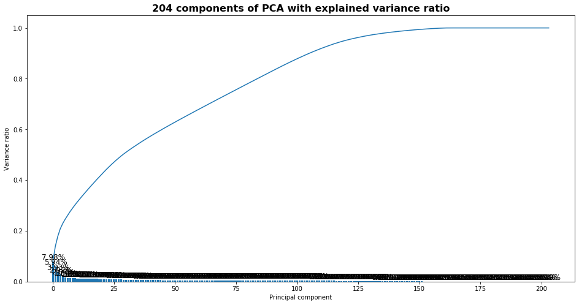

```python
# Investigate the variance accounted for by each principal component.
def pca_variance_ratios(pca, n_highest = 0):
    """
    plots n_highest variance ratios from fit pca model as single and cumsum values

    Parameters:
    pca [sklearn.PCA] - fit pca model
    n_highest [int]   - number of top components to be displayed, if null (default) all will be plotted

    Returns:
    None
    """

    #get the necessary data
    if n_highest == 0:
        n_highest = len(pca.explained_variance_ratio_)


    var_values = pca.explained_variance_ratio_[:n_highest]
    var_values_cum = np.cumsum(var_values)
    x_ticks = range(n_highest)

    #plot data
    fig = plt.figure(figsize = (16,8))
    plt.plot(x_ticks, var_values_cum)
    plt.bar(x_ticks, var_values)

    #add values as annotations
    for i in range(n_highest):
        plt.annotate(r"%s%%" % ((str(var_values[i]*100)[:4])), (x_ticks[i]+0.2, var_values[i]), va="bottom", ha="center", fontsize=12)


    #styling
    plt.xlabel("Principal component")
    plt.ylabel("Variance ratio")
    plt.title(f"{n_highest} components of PCA with explained variance ratio", fontweight = 'bold', fontsize = 16)
    plt.show()

    #TOD DO: add some prints with numeric analysis of data

    return None

pca_variance_ratios(pca, n_highest = 0)
```

At around 125 principal components the curve flattens significantly. Only 30 principal components lead to a cumulative explained variance ratio of around 50%.

```python
# Re-apply PCA to the data while selecting for number of components to retain.
pca = PCA(n_components=30)
azdias_pca = pca.fit_transform(azdias_ss)
```

### Discussion 2.2: Perform Dimensionality Reduction

So a decision was made to use 30 principal components and thereby ~50% explained variance for a first approach.

### Step 2.3: Interpret Principal Components

Now that we have our transformed principal components, it's a nice idea to **check out the weight of each variable on the first few components** to see if they can be interpreted in some fashion.

As a reminder, each principal component is a unit vector that points in the direction of highest variance (after accounting for the variance captured by earlier principal components). The further a weight is from zero, the more the principal component is in the direction of the corresponding feature. **If two features have large weights of the same sign (both positive or both negative), then increases in one tend expect to be associated with increases in the other**. To contrast, features with different signs can be expected to show a **negative correlation**: increases in one variable should result in a decrease in the other.

- To investigate the features, you should map each weight to their corresponding feature name, then sort the features according to weight. The most interesting features for each principal component, then, will be those at the beginning and end of the sorted list. **Use the data dictionary document to help you understand these most prominent features, their relationships, and what a positive or negative value on the principal component might indicate**.
- You should **investigate and interpret feature associations from the first three principal components** in this substep. To help facilitate this, you should write a function that you can call at any time to print the sorted list of feature weights, for the *i*-th principal component. This might come in handy in the next step of the project, when you interpret the tendencies of the discovered clusters.

```
LP_STATUS_GROB_1.0        0.188309
HH_EINKOMMEN_SCORE        0.178808
CAMEO_INTL_2015_WEALTH    0.174187
PLZ8_ANTG3                0.167170
KBA05_GBZ                -0.171147
KBA05_ANTG1              -0.183565
MOBI_REGIO               -0.193842
FINANZ_MINIMALIST        -0.196422
Name: 0, dtype: float64
```

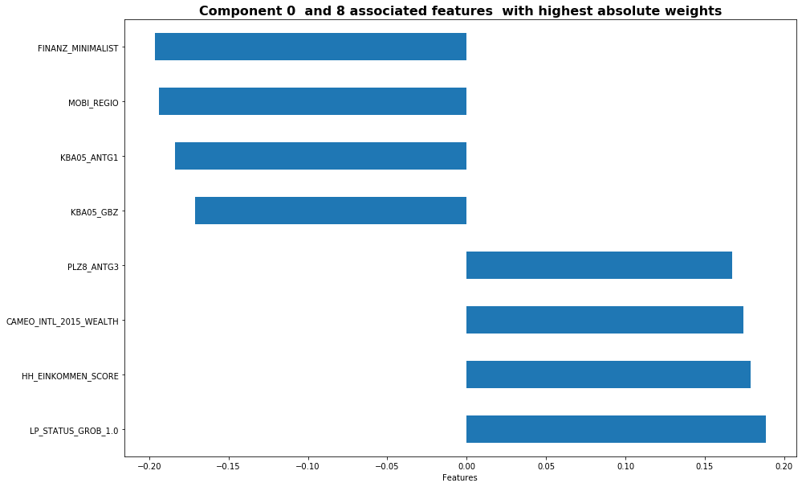

```python
# Map weights for the first principal component to corresponding feature names
# and then print the linked values, sorted by weight.
# HINT: Try defining a function here or in a new cell that you can reuse in the
# other cells.

def pca_component_weights(pca, df, n = 0, n_feat = 5):
    """
    prints weights and associated features for n-th component
    """

    all_features = list(df.columns)

    #combine to a dataframe (easier with sorting both) and slice one row (one component)
    weights = pd.DataFrame(pca.components_, columns = all_features).iloc[n,:]
    weights = weights.sort_values(ascending = False)
    weights = pd.concat([weights.iloc[:n_feat],weights.iloc[-n_feat:]], axis = 0)
    print(weights)

    fig, axes = plt.subplots(figsize = (15,10))
    weights.plot(kind = 'barh')

    #styling
    axes.set_xlabel('Feature weights')
    axes.set_xlabel('Features')
    axes.set_title(f"Component {n}  and {2*n_feat} associated features  with highest absolute weights", fontweight = 'bold', fontsize = 16)
    plt.show()

    return None

pca_component_weights(pca, azdias, 0, 4)
```

```
ALTERSKATEGORIE_GROB            0.212209
FINANZ_VORSORGER                0.193856
ZABEOTYP_3                      0.191267
SEMIO_ERL                       0.172936
RETOURTYP_BK_S                  0.150482
FINANZ_UNAUFFAELLIGER          -0.199555
FINANZ_SPARER                  -0.200465
SEMIO_REL                      -0.202050
PRAEGENDE_JUGENDJAHRE_DECADE   -0.220374
GEBURTSJAHR_NEU                -0.223801
Name: 1, dtype: float64
```

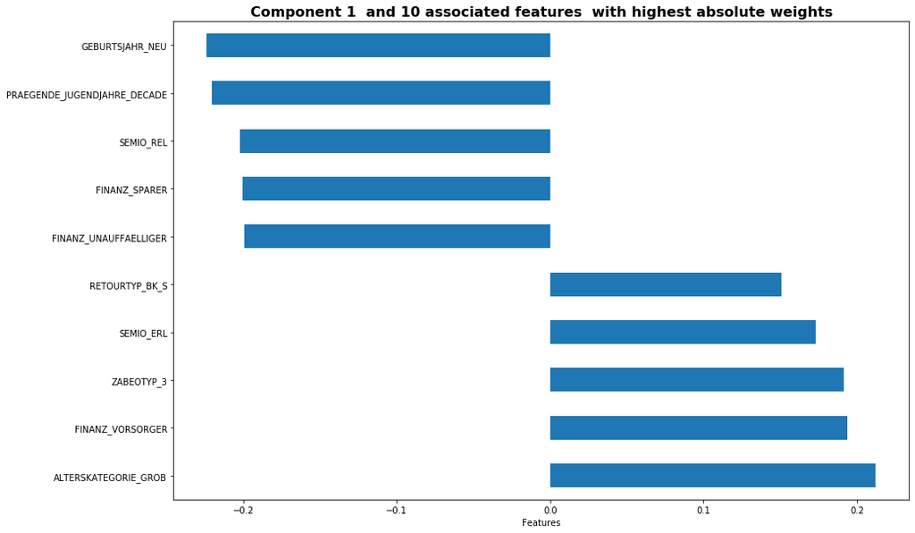

```python
# Map weights for the second principal component to corresponding feature names
# and then print the linked values, sorted by weight.
pca_component_weights(pca, azdias, 1, 5)
```

```
ANREDE_KZ_1    0.327811
SEMIO_VERT     0.302960
SEMIO_FAM      0.244792
SEMIO_SOZ      0.240282
SEMIO_KRIT    -0.242446
SEMIO_DOM     -0.264528
SEMIO_KAEM    -0.297395
ANREDE_KZ_2   -0.327811
Name: 2, dtype: float64
```

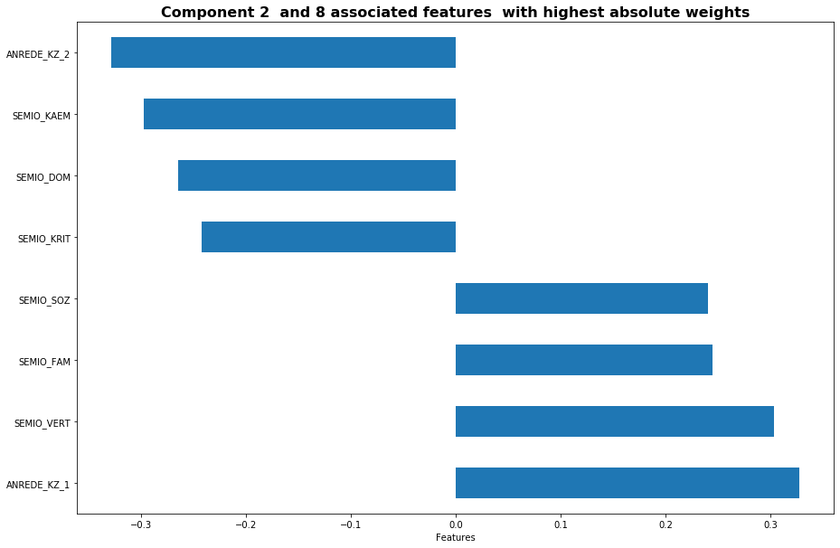

```python
# Map weights for the third principal component to corresponding feature names
# and then print the linked values, sorted by weight.
pca_component_weights(pca, azdias, 2, 4)
```

### Discussion 2.3: Interpret Principal Components

**Component 0**

Component 0 seems to be a proxy for households wealth populated neighbourhood population density.

**Component 1**

Component 1 seems to be a proxy for a age and traditional psychographic dimensions.

**Component 2**

- Negative:
  - ANREDE_KZ_2: female
  - SEMIO_KAEM: combative attitude, 1 highest affinity, 7 lowest affinity
  - SEMIO_DOM: dominant-minded, 1 highest affinity, 7 lowest affinity
  - SEMIO_KRIT: critical-minded, 1 highest affinity, 7 lowest affinity
- Positive:
  - ANREDE_KZ_1: male
  - SEMIO_VERT: dreamful, 1 highest affinity, 7 lowest affinity
  - SEMIO_FAM: family-minded
  - SEMIO_SOZ: socially-minded

Component 2 seems to be a proxy for sex and related psychographic dimensions.

## Step 3: Clustering

### Step 3.1: Apply Clustering to General Population

You've assessed and cleaned the demographics data, then scaled and transformed them. Now, it's time to see how the data clusters in the principal components space. In this substep, you will **apply k-means clustering to the dataset** and use the average within-cluster distances from each point to their assigned cluster's centroid to **decide on a number of clusters to keep**.

- Use sklearn's KMeans class to perform k-means clustering on the PCA-transformed data.
- Then, compute the average difference from each point to its assigned cluster's center. **Hint**: The KMeans object's `.score()` method might be useful here, but note that in sklearn, scores tend to be defined so that larger is better. Try applying it to a small, toy dataset, or use an internet search to help your understanding.
- Perform the above two steps for a number of different cluster counts. You can then see how the average distance decreases with an increasing number of clusters. However, each additional cluster provides a smaller net benefit. Use this fact to select a final number of clusters in which to group the data. **Warning**: because of the large size of the dataset, it can take a long time for the algorithm to resolve. The more clusters to fit, the longer the algorithm will take. You should test for cluster counts through **at least 10 clusters to get the full picture, but you shouldn't need to test for a number of clusters above about 30**.
- Once you've selected a final number of clusters to use, **re-fit a KMeans** instance to perform the clustering operation. Make sure that you also obtain the cluster assignments for the general demographics data, since you'll be using them in the final Step 3.3.

```python
# Over a number of different cluster counts...
n_clusters = 150
avg_distances = []

for n in range(1, n_clusters+1):
    kmeans = KMeans(n_clusters=n, max_iter = 100)

    #try subset first adn refit on complete dataset after decision on number of clusters
    idx = np.random.randint(5000, size = 5000)
    subset = azdias_pca[idx]
    kmeans.fit(subset)

    # compute the average within-cluster distances.
    #use inertia_float: Sum of squared distances of samples to their closest cluster center.
    #avg_dist = kmeans.inertia_/azdias_pca.shape[0]
    avg_dist = kmeans.inertia_/subset.shape[0]
    print(f"{n} cluster(s). Average squared distance of samples to closest cluster center: {avg_dist}")
    avg_distances.append(avg_dist)
```

```
1 cluster(s). Average squared distance of samples to closest cluster center: 100.1620880143259
2 cluster(s). Average squared distance of samples to closest cluster center: 86.40372585995347
3 cluster(s). Average squared distance of samples to closest cluster center: 80.65658459495214
4 cluster(s). Average squared distance of samples to closest cluster center: 78.88516302952031
5 cluster(s). Average squared distance of samples to closest cluster center: 74.4200776473881
6 cluster(s). Average squared distance of samples to closest cluster center: 71.7239391713715
7 cluster(s). Average squared distance of samples to closest cluster center: 71.20201817616065
8 cluster(s). Average squared distance of samples to closest cluster center: 69.11514350743266
9 cluster(s). Average squared distance of samples to closest cluster center: 68.0127060887861
10 cluster(s). Average squared distance of samples to closest cluster center: 65.80535376067077
11 cluster(s). Average squared distance of samples to closest cluster center: 63.75585567214622
12 cluster(s). Average squared distance of samples to closest cluster center: 62.37839057167643
13 cluster(s). Average squared distance of samples to closest cluster center: 62.17795300089245
14 cluster(s). Average squared distance of samples to closest cluster center: 60.59813320344303
15 cluster(s). Average squared distance of samples to closest cluster center: 59.96268170193939
```

[output cut: 135 more lines]

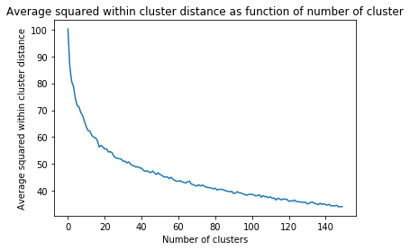

```python
# Investigate the change in within-cluster distance across number of clusters.
# HINT: Use matplotlib's plot function to visualize this relationship.
plt.plot(avg_distances)
plt.title("Average squared within cluster distance as function of number of cluster")
plt.xlabel("Number of clusters")
#TO DO xlabels start from 1!
plt.ylabel("Average squared within cluster distance")
plt.show()
```

```python
# Re-fit the k-means model with the selected number of clusters and obtain
# cluster predictions for the general population demographics data.
n_clusters = 50
idx = np.random.randint(50000, size = 50000)
subset = azdias_pca[idx]
kmeans = KMeans(n_clusters=n_clusters, max_iter = 300)
kmeans.fit(subset)
```

```
KMeans(algorithm='auto', copy_x=True, init='k-means++', max_iter=300,
       n_clusters=50, n_init=10, n_jobs=None, precompute_distances='auto',
       random_state=None, tol=0.0001, verbose=0)
```

```python
predictions =  kmeans.predict(azdias_pca)
```

### Step 3.2: Apply All Steps to the Customer Data

Now that you have clusters and cluster centers for the general population, it's time to **see how the customer data maps on to those clusters**. Take care to not confuse this for re-fitting all of the models to the customer data. Instead, you're going to use the fits from the general population to clean, transform, and cluster the customer data. In the last step of the project, you will interpret how the general population fits apply to the customer data.

- Don't forget when loading in the customers data, that it is semicolon (`;`) delimited.
- Apply the same feature wrangling, selection, and engineering steps to the customer demographics using the `clean_data()` function you created earlier. (You can assume that the customer demographics data has similar meaning behind missing data patterns as the general demographics data.)
- Use the sklearn objects from the general demographics data, and apply their transformations to the customers data. That is, you should not be using a `.fit()` or `.fit_transform()` method to re-fit the old objects, nor should you be creating new sklearn objects! Carry the data through the feature scaling, PCA, and clustering steps, obtaining cluster assignments for all of the data in the customer demographics data.

```python
# Load in the customer demographics data.
customers = pd.read_csv('Udacity_CUSTOMERS_Subset.csv', delimiter = ';')
customers_orig = customers.copy()
```

```python
# Apply preprocessing, feature transformation, and clustering from the general
# demographics onto the customer data, obtaining cluster predictions for the
# customer demographics data.
customers, customers_high_missing = clean_data(customers)
```

```python
customers.info()
#as a first approach add columns in census dataset if not in customer dataset e.g. not created by one-hot encoding adn set 0
for column in list(azdias_clean.columns):
    if column not in list(customers.columns):
        customers[column] = 0
```

```
<class 'pandas.core.frame.DataFrame'>
Int64Index: 115643 entries, 0 to 191651
Columns: 202 entries, ALTERSKATEGORIE_GROB to CAMEO_INTL_2015_LIFE_STAGE
dtypes: float64(40), int64(20), uint8(142)
memory usage: 69.5 MB
```

```python
customers_ss = scaler.transform(customers)
```

```python
customers_pca = pca.transform(customers_ss)
customers_predictions = kmeans.predict(customers_pca)
```

### Step 3.3: Compare Customer Data to Demographics Data

At this point, **you have clustered data based on demographics of the general population of Germany**, and seen how the customer data for a mail-order sales company maps onto those demographic clusters. In this final substep, you will compare the two cluster distributions to see where the strongest customer base for the company is.

Consider the proportion of persons in each cluster for the general population, and the proportions for the customers. **If we think the company's customer base to be universal, then the cluster assignment proportions should be fairly similar between the two**. If there are only particular segments of the population that are interested in the company's products, then we should see a mismatch from one to the other. If there is a higher proportion of persons in a cluster for the customer data compared to the general population (**e.g. 5% of persons are assigned to a cluster for the general population, but 15% of the customer data is closest to that cluster's centroid**) then that suggests the people in that cluster to be a target audience for the company. On the other hand, the proportion of the data in a cluster being larger in the general population than the customer data (e.g. only 2% of customers closest to a population centroid that captures 6% of the data) suggests that group of persons to be outside of the target demographics.

Take a look at the following points in this step:

- Compute the **proportion of data points in each cluster for the general population and the customer data**. Visualizations will be useful here: both for the individual dataset proportions, but also to visualize the ratios in cluster representation between groups. Seaborn's [`countplot()`](https://seaborn.pydata.org/generated/seaborn.countplot.html) or [`barplot()`](https://seaborn.pydata.org/generated/seaborn.barplot.html) function could be handy.
  - Recall the analysis you performed in step 1.1.3 of the project, where you separated out certain data points from the dataset if they had more than a specified threshold of missing values. If you found that this group was qualitatively different from the main bulk of the data, you should **treat this as an additional data cluster in this analysis**. Make sure that you account for the number of data points in this subset, for both the general population and customer datasets, when making your computations!
- **Which cluster or clusters are overrepresented in the customer dataset compared to the general population?** Select at least one such cluster and infer what kind of people might be represented by that cluster. Use the principal component interpretations from step 2.3 or look at additional components to help you make this inference. Alternatively, you can use the `.inverse_transform()` method of the PCA and StandardScaler objects to transform centroids back to the original data space and interpret the retrieved values directly.
- Perform a similar investigation for the underrepresented clusters. **Which cluster or clusters are underrepresented in the customer dataset** compared to the general population, and what kinds of people are typified by these clusters?

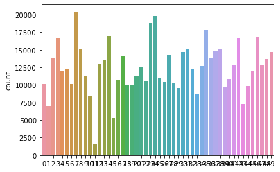

```python
sns.countplot(predictions)
plt.show()
```

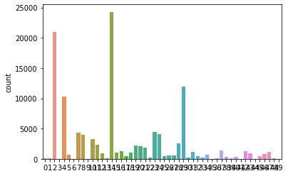

```python
sns.countplot(customers_predictions)
plt.show()
```

```
    df_clusters  df_2_clusters  df_clusters - df_2_clusters
0      0.016190       0.000994                     0.015196
1      0.011269       0.000882                     0.010387
2      0.022153       0.181688                    -0.159535
3      0.026731       0.000173                     0.026558
4      0.019114       0.088747                    -0.069633
5      0.019624       0.005923                     0.013701
6      0.016328       0.000035                     0.016294
7      0.032763       0.036872                    -0.004110
8      0.024290       0.033776                    -0.009486
9      0.018018       0.000052                     0.017966
10     0.013633       0.028355                    -0.014722
11     0.002571       0.019837                    -0.017266
12     0.020893       0.007938                     0.012955
13     0.021599       0.000337                     0.021262
```

[output cut: 36 more lines]

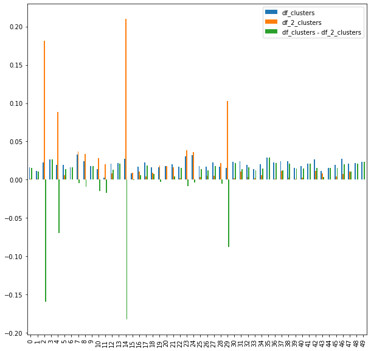

```python
# Compare the proportion of data in each cluster for the customer data to the
# proportion of data in each cluster for the general population.
def plot_cluster_ratios(df, df_2):
    """
    """

    df = pd.DataFrame(df, columns = ['df_clusters'])
    df_2 = pd.DataFrame(df_2, columns = ['df_2_clusters'])


    df_ratios = pd.DataFrame(df['df_clusters'].value_counts()/df['df_clusters'].count())
    df_2_ratios = pd.DataFrame(df_2['df_2_clusters'].value_counts()/df_2['df_2_clusters'].count())

    ratios = pd.concat([df_ratios, df_2_ratios], axis = 1)
    #ratios.columns =  ['df', 'df_2']

    ratios['df_clusters - df_2_clusters'] = ratios['df_clusters'] - ratios['df_2_clusters']
    print(ratios)


    #fig, ax = plt.subplots(1,3, sharey = True, figsize = (10,10))
    ratios.plot(kind = 'bar', figsize = (10,10))
    #sns.barplot(x = data.index, y = 'df_clusters', data = ratios, ax = ax[0])
    #sns.barplot(x = data.index, y = 'df_2_cluster', data = ratios, ax = ax[1])
    #sns.barplot(x = data.index, y = 'df_clusters - df_2_clusters', data = ratios, ax = ax[2])

    plt.show()

plot_cluster_ratios(predictions, customers_predictions)
```

Clusters 2,4,14 and 29 is significantly overrepresented in customer dataset. Let's compare values of principal components for cluster group x vs. other clusters.

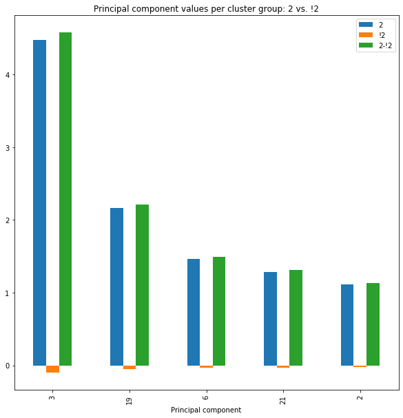

```python
def cluster_component_values(df_pca, n_cluster, n_comps):
    pca_scores_2 = pd.concat([pd.DataFrame(df_pca[predictions == n_cluster, :]).mean(), pd.DataFrame(df_pca[predictions != n_cluster, :],).mean()], axis = 1)
    pca_scores_2.columns = [n_cluster, f'!{n_cluster}']
    pca_scores_2[f'{n_cluster}-!{n_cluster}'] = pca_scores_2[n_cluster] - pca_scores_2[f'!{n_cluster}']
    pca_scores_2.sort_values(by = f'{n_cluster}-!{n_cluster}', ascending = False).iloc[:n_comps,:].plot(kind = 'bar', figsize = (10,10))
    plt.title(f"Principal component values per cluster group: {n_cluster} vs. !{n_cluster}")
    plt.xlabel("Principal component")
    plt.show()

cluster_component_values(azdias_pca, 2, 5)
```

Values of principal component 3 are significatnly higher for observations in cluster 2. Let's check associated features.

```
PRAEGENDE_JUGENDJAHRE_MOVEMENT    0.288556
GREEN_AVANTGARDE_1                0.288556
LP_STATUS_GROB_5.0                0.219904
LP_STATUS_FEIN_10.0               0.219904
EWDICHTE                          0.207743
INNENSTADT                       -0.166318
BALLRAUM                         -0.168835
LP_STATUS_FEIN_9.0               -0.199176
LP_STATUS_GROB_4.0               -0.206034
GREEN_AVANTGARDE_0               -0.288556
Name: 3, dtype: float64
```

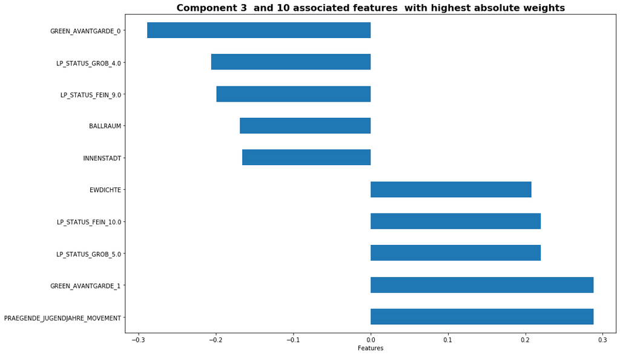

```python
pca_component_weights(pca, azdias, 3, 5)
```

A sanity check can be performed by calculating aggregates for some of those features in both original datasets. Aggregates for GREEN_AVANTGARDE, LP_STATUS_GROB and LP_STATUS_FEIN must be higher.

```python
#check with original datasets
print('census')
print(azdias_orig[['GREEN_AVANTGARDE', 'LP_STATUS_GROB', 'LP_STATUS_FEIN']].describe())
print('customers')
print(customers_orig[['GREEN_AVANTGARDE', 'LP_STATUS_GROB', 'LP_STATUS_FEIN']].describe())
```

```
census
       GREEN_AVANTGARDE  LP_STATUS_GROB  LP_STATUS_FEIN
count     891221.000000   886367.000000   886367.000000
mean           0.196612        2.432575        4.791151
std            0.397437        1.474315        3.425305
min            0.000000        1.000000        1.000000
25%            0.000000        1.000000        2.000000
50%            0.000000        2.000000        4.000000
75%            0.000000        4.000000        9.000000
max            1.000000        5.000000       10.000000
customers
       GREEN_AVANTGARDE  LP_STATUS_GROB  LP_STATUS_FEIN
count     191652.000000   188439.000000   188439.000000
mean           0.367171        3.209251        6.687910
std            0.482035        1.436958        3.090573
min            0.000000        1.000000        1.000000
25%            0.000000        2.000000        5.000000
50%            0.000000        3.000000        7.000000
75%            1.000000        5.000000       10.000000
max            1.000000        5.000000       10.000000
```

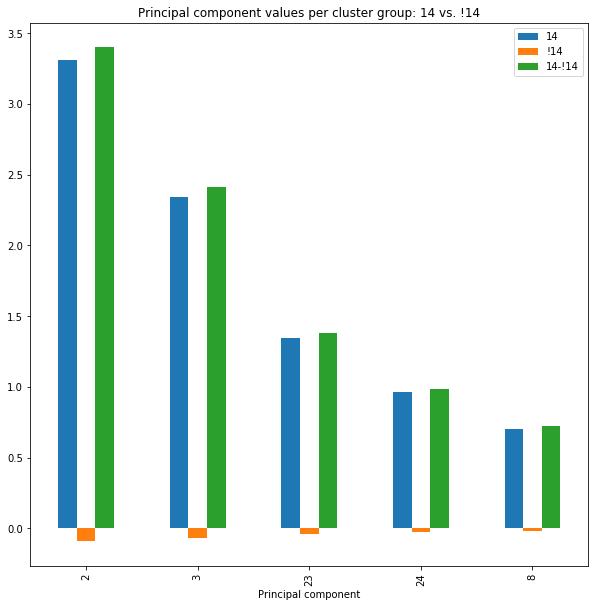

```python
cluster_component_values(azdias_pca, 14, 5)
```

Principal components 2 and 3 seem to be dominating.

Now let's check clusters 4 and 29.

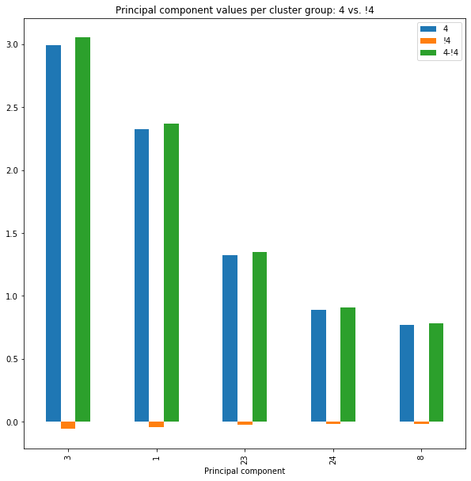

```python
cluster_component_values(azdias_pca, 4, 5)
```

Again component 3 and additionally component 1.

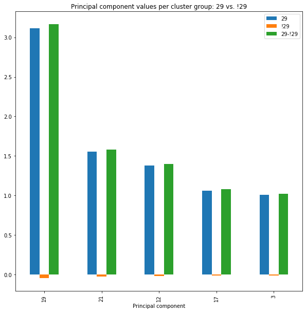

```python
cluster_component_values(azdias_pca, 29, 5)
```

New important componant: 19.

```
CAMEO_DEUG_2015_1      0.276423
LP_FAMILIE_GROB_3.0    0.264453
SOHO_KZ_0.0            0.210123
CAMEO_DEUG_2015_7      0.177437
LP_FAMILIE_FEIN_5.0    0.169703
LP_FAMILIE_FEIN_8.0   -0.155024
CAMEO_DEUG_2015_9     -0.173133
LP_FAMILIE_GROB_4.0   -0.208607
SOHO_KZ_1.0           -0.210123
CAMEO_DEUG_2015_3     -0.232338
Name: 19, dtype: float64
```

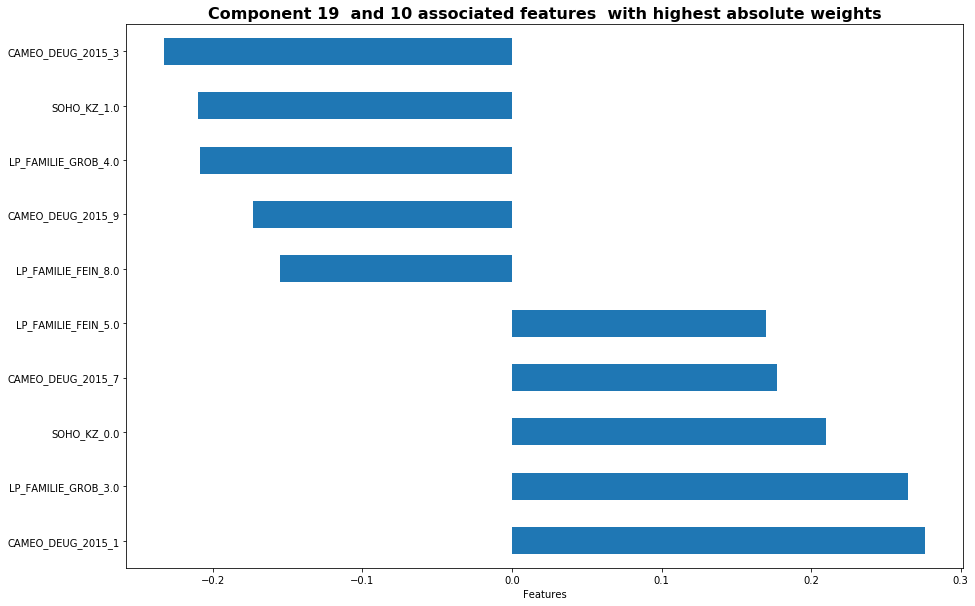

```python
pca_component_weights(pca, azdias, 19, 5)
```

All four clusters are dominated by a small number of principal components: 1,2,3 and 19. Component 3 and 1 seem to play a major role.

Let's check our findings: values for components 1-3 in customer dataset must be higher and values for component 0 lower than in population dataset.

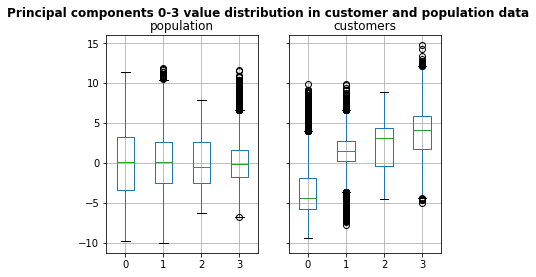

```python
fig, axes = plt.subplots(1,2, sharey = True)
axes[0].set_title("population")
pd.DataFrame(azdias_pca[:, :4]).boxplot(ax = axes[0])
axes[1].set_title("customers")
pd.DataFrame(customers_pca[:, :4]).boxplot(ax = axes[1])
plt.suptitle("Principal components 0-3 value distribution in customer and population data", fontweight = 'bold')
plt.show()
```

```python
# What kinds of people are part of a cluster that is underrepresented in the
# customer data compared to the general population?
```

Especially Clusters 3 and 35 are underrepresented in Customer dataset (0 or nearly 0% share).

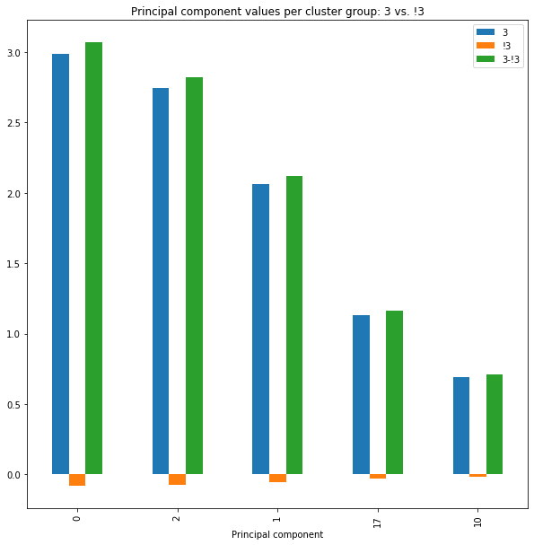

```python
cluster_component_values(azdias_pca, 3, 5)
```

Again components 0, 2 and 1.

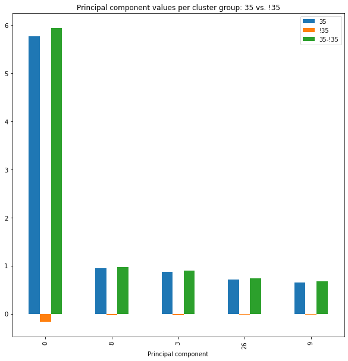

```python
cluster_component_values(azdias_pca, 35, 5)
```

And additionally component 0.

**Principal components 0,1,2 and 3 play a major role in cluster definition.**

Are parts of the dataset with high number of dataset an additonal cluster? Let's compare their share of the complete datasets.

```python
1 - customers.shape[0]/customers_orig.shape[0]
```

```
0.39659904410076596
```

```python
1 -azdias_clean.shape[0]/azdias_orig.shape[0]
```

```
0.3007222675408232
```

Rows with more than 20% missing data have a higher share in the customer dataset. But without knowdledge of the whole data gathering mechanism that produced both datasets this cluster should remain discarded.

### Discussion 3.3: Compare Customer Data to Demographics Data

By comparing cluster distribution in both the population and customer dataset we get 6 distinct clusters that are either under- or overrepresented in the customer dataset compared to the population dataset.

Components 0-2 were already been analyzed in discussion 2.3. The main points:

- component 0: high values for poor households living in densely populated neighbourhoods
- component 1: high values for high age and traditional psychographic dimensions
- component 2: high values for male sex and related psychographic dimensions
- **component 3 (new)**: high values for (green) avantgarde

These findings lead to to the hypothesis that mainly male and traditional people, who are part of a green avantgarde, tend to be customers of the provided mail-order service.

Whereas poor housholds from densely populated neighbourhoods show a lower probability to become customers.

Rows with more than 20% missing data have a higher share in the customer dataset (30% vs. 39%). But without knowledge of the data gathering mechanism that produced both datasets this cluster should be discarded.

> Congratulations on making it this far in the project! Before you finish, make sure to check through the entire notebook from top to bottom to make sure that your analysis follows a logical flow and all of your findings are documented in **Discussion** cells. Once you've checked over all of your work, you should export the notebook as an HTML document to submit for evaluation. You can do this from the menu, navigating to **File -> Download as -> HTML (.html)**. You will submit both that document and this notebook for your project submission.